# 4. Further evolutionary transcriptomics analyses (addressing reviewers)

# Reporting the difference in TAI using the `pairwiseTest()` in *Fucus*

```r
library(tidyverse)
library(myTAI)
```

### Load PES

non-transformed

```r
Fd_PES_matSP <-
  readr::read_csv(file = "data/Fd_PES_matSP.csv", show_col_types = FALSE)
Fs_PES_F_matSP <-
  readr::read_csv(file = "data/Fs_PES_F_matSP.csv", show_col_types = FALSE)
Fs_PES_M_matSP <-
  readr::read_csv(file = "data/Fs_PES_M_matSP.csv", show_col_types = FALSE)
```

sqrt-tranformed

```r
Fd_PES_matSP.sqrt <-
  readr::read_csv(file = "data/Fd_PES_matSP.sqrt.csv", show_col_types = FALSE)
Fs_PES_F_matSP.sqrt <-
  readr::read_csv(file = "data/Fs_PES_F_matSP.sqrt.csv", show_col_types = FALSE)
Fs_PES_M_matSP.sqrt <-
  readr::read_csv(file = "data/Fs_PES_M_matSP.sqrt.csv", show_col_types = FALSE)
```

log2-tranformed

```r
Fd_PES_matSP.log2 <-
  readr::read_csv(file = "data/Fd_PES_matSP.log2.csv", show_col_types = FALSE)
Fs_PES_F_matSP.log2 <-
  readr::read_csv(file = "data/Fs_PES_F_matSP.log2.csv", show_col_types = FALSE)
Fs_PES_M_matSP.log2 <-
  readr::read_csv(file = "data/Fs_PES_M_matSP.log2.csv", show_col_types = FALSE)
```

## `PairwiseTest()` for matSP reptip vs vegtip

non-tranformed

```r
Fd_pairwisetest <-
        myTAI::PairwiseTest(
                ExpressionSet = Fd_PES_matSP,
                modules = list(contrast1 = 2, contrast2 = 4),
                altHypothesis = "greater",
                permutations = 1000)$p.value
```

```
##
## [ Number of Eigen threads that are employed on your machine: 8 ]
##
## [ Computing age assignment permutations for test statistic ... ]
## [=========================================] 100%
## [ Computing variances of permuted transcriptome signatures ... ]
```

```r
Fs_F_pairwisetest <-
        myTAI::PairwiseTest(
                ExpressionSet = Fs_PES_F_matSP,
                modules = list(contrast1 = 2, contrast2 = 4),
                altHypothesis = "greater",
                permutations = 1000)$p.value
```

```
##
## [ Number of Eigen threads that are employed on your machine: 8 ]
##
## [ Computing age assignment permutations for test statistic ... ]
## [=========================================] 100%
## [ Computing variances of permuted transcriptome signatures ... ]
```

```r
Fs_M_pairwisetest <-
        myTAI::PairwiseTest(
                ExpressionSet = Fs_PES_M_matSP,
                modules = list(contrast1 = 2, contrast2 = 4),
                altHypothesis = "greater",
                permutations = 1000)$p.value
```

```
##
## [ Number of Eigen threads that are employed on your machine: 8 ]
##
## [ Computing age assignment permutations for test statistic ... ]
## [=========================================] 100%
## [ Computing variances of permuted transcriptome signatures ... ]
```

sqrt-tranformed

```r
Fd_pairwisetest.sqrt <-
        myTAI::PairwiseTest(
                ExpressionSet = Fd_PES_matSP.sqrt,
                modules = list(contrast1 = 2, contrast2 = 4),
                altHypothesis = "greater",
                permutations = 1000)$p.value
```

```
##
## [ Number of Eigen threads that are employed on your machine: 8 ]
##
## [ Computing age assignment permutations for test statistic ... ]
## [=========================================] 100%
## [ Computing variances of permuted transcriptome signatures ... ]
```

```r
Fs_F_pairwisetest.sqrt <-
        myTAI::PairwiseTest(
                ExpressionSet = Fs_PES_F_matSP.sqrt,
                modules = list(contrast1 = 2, contrast2 = 4),
                altHypothesis = "greater",
                permutations = 1000)$p.value
```

```
##
## [ Number of Eigen threads that are employed on your machine: 8 ]
##
## [ Computing age assignment permutations for test statistic ... ]
## [=========================================] 100%
## [ Computing variances of permuted transcriptome signatures ... ]
```

```r
Fs_M_pairwisetest.sqrt <-
        myTAI::PairwiseTest(
                ExpressionSet = Fs_PES_M_matSP.sqrt,
                modules = list(contrast1 = 2, contrast2 = 4),
                altHypothesis = "greater",
                permutations = 1000)$p.value
```

```
##
## [ Number of Eigen threads that are employed on your machine: 8 ]
##
## [ Computing age assignment permutations for test statistic ... ]
## [=========================================] 100%
## [ Computing variances of permuted transcriptome signatures ... ]
```

log2-tranformed

```r
Fd_pairwisetest.log2 <-
        myTAI::PairwiseTest(
                ExpressionSet = Fd_PES_matSP.log2,
                modules = list(contrast1 = 2, contrast2 = 4),
                altHypothesis = "greater",
                permutations = 1000)$p.value
```

```
##
## [ Number of Eigen threads that are employed on your machine: 8 ]
##
## [ Computing age assignment permutations for test statistic ... ]
## [=========================================] 100%
## [ Computing variances of permuted transcriptome signatures ... ]
```

```r
Fs_F_pairwisetest.log2 <-
        myTAI::PairwiseTest(
                ExpressionSet = Fs_PES_F_matSP.log2,
                modules = list(contrast1 = 2, contrast2 = 4),
                altHypothesis = "greater",
                permutations = 1000)$p.value
```

```
##
## [ Number of Eigen threads that are employed on your machine: 8 ]
##
## [ Computing age assignment permutations for test statistic ... ]
## [=========================================] 100%
## [ Computing variances of permuted transcriptome signatures ... ]
```

```r
Fs_M_pairwisetest.log2 <-
        myTAI::PairwiseTest(
                ExpressionSet = Fs_PES_M_matSP.log2,
                modules = list(contrast1 = 2, contrast2 = 4),
                altHypothesis = "greater",
                permutations = 1000)$p.value
```

```
##
## [ Number of Eigen threads that are employed on your machine: 8 ]
##
## [ Computing age assignment permutations for test statistic ... ]
## [=========================================] 100%
## [ Computing variances of permuted transcriptome signatures ... ]
```

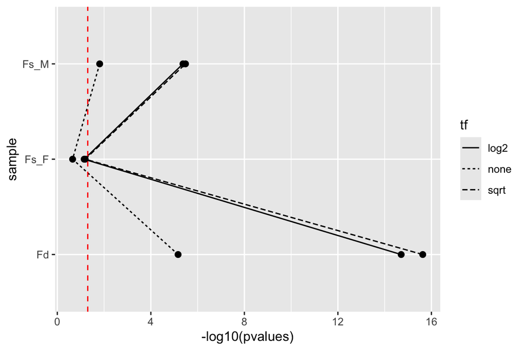

```r
p_res <- data.frame(
        pvalues = c(Fd_pairwisetest, Fs_M_pairwisetest, Fs_F_pairwisetest,
          Fd_pairwisetest.sqrt, Fs_M_pairwisetest.sqrt, Fs_F_pairwisetest.sqrt,
          Fd_pairwisetest.log2, Fs_M_pairwisetest.log2, Fs_F_pairwisetest.log2),
        species = c("Fd", "Fs", "Fs", "Fd", "Fs", "Fs", "Fd", "Fs", "Fs"),
        sex = c("mixed", "M", "F", "mixed", "M", "F", "mixed", "M", "F"),
        tf = c("none", "none", "none",
                           "sqrt", "sqrt", "sqrt",
                           "log2", "log2", "log2"),
        sample = c("Fd", "Fs_M", "Fs_F", "Fd", "Fs_M", "Fs_F", "Fd", "Fs_M", "Fs_F")
)

p_res |>
        ggplot2::ggplot(aes(x = sample, y = -log10(pvalues), linetype = tf, group = tf)) +
        ggplot2::geom_line() +
        ggplot2::geom_point(size = 2) +
        ggplot2::geom_hline(yintercept = -log10(0.05), colour = "red", linetype = 2) +
        ggplot2::coord_flip()
```

```r
p_res
```

| pvalues | species | sex | tf | sample |
| --- | --- | --- | --- | --- |
| 6.840433e-06 | Fd | mixed | none | Fd |
| 1.545576e-02 | Fs | M | none | Fs_M |
| 2.222216e-01 | Fs | F | none | Fs_F |
| 2.345936e-16 | Fd | mixed | sqrt | Fd |
| 3.299703e-06 | Fs | M | sqrt | Fs_M |
| 6.419488e-02 | Fs | F | sqrt | Fs_F |
| 1.961659e-15 | Fd | mixed | log2 | Fd |
| 4.222928e-06 | Fs | M | log2 | Fs_M |
| 7.102473e-02 | Fs | F | log2 | Fs_F |

## `PairwiseTest()` for matSP reptip vs all

non-tranformed

```r
Fd_pairwisetest <-
        myTAI::PairwiseTest(
                ExpressionSet = Fd_PES_matSP,
                modules = list(contrast1 = 2, contrast2 = c(1,3,4)),
                altHypothesis = "greater",
                permutations = 1000)$p.value
```

```
##
## [ Number of Eigen threads that are employed on your machine: 8 ]
##
## [ Computing age assignment permutations for test statistic ... ]
## [=========================================] 100%
## [ Computing variances of permuted transcriptome signatures ... ]
```

```r
Fs_F_pairwisetest <-
        myTAI::PairwiseTest(
                ExpressionSet = Fs_PES_F_matSP,
                modules = list(contrast1 = 2, contrast2 = c(1,3,4)),
                altHypothesis = "greater",
                permutations = 1000)$p.value
```

```
##
## [ Number of Eigen threads that are employed on your machine: 8 ]
##
## [ Computing age assignment permutations for test statistic ... ]
## [=========================================] 100%
## [ Computing variances of permuted transcriptome signatures ... ]
```

```r
Fs_M_pairwisetest <-
        myTAI::PairwiseTest(
                ExpressionSet = Fs_PES_M_matSP,
                modules = list(contrast1 = 2, contrast2 = c(1,3,4)),
                altHypothesis = "greater",
                permutations = 1000)$p.value
```

```
##
## [ Number of Eigen threads that are employed on your machine: 8 ]
##
## [ Computing age assignment permutations for test statistic ... ]
## [=========================================] 100%
## [ Computing variances of permuted transcriptome signatures ... ]
```

sqrt-tranformed

```r
Fd_pairwisetest.sqrt <-
        myTAI::PairwiseTest(
                ExpressionSet = Fd_PES_matSP.sqrt,
                modules = list(contrast1 = 2, contrast2 = c(1,3,4)),
                altHypothesis = "greater",
                permutations = 1000)$p.value
```

```
##
## [ Number of Eigen threads that are employed on your machine: 8 ]
##
## [ Computing age assignment permutations for test statistic ... ]
## [=========================================] 100%
## [ Computing variances of permuted transcriptome signatures ... ]
```

```r
Fs_F_pairwisetest.sqrt <-
        myTAI::PairwiseTest(
                ExpressionSet = Fs_PES_F_matSP.sqrt,
                modules = list(contrast1 = 2, contrast2 = c(1,3,4)),
                altHypothesis = "greater",
                permutations = 1000)$p.value
```

```
##
## [ Number of Eigen threads that are employed on your machine: 8 ]
##
## [ Computing age assignment permutations for test statistic ... ]
## [=========================================] 100%
## [ Computing variances of permuted transcriptome signatures ... ]
```

```r
Fs_M_pairwisetest.sqrt <-
        myTAI::PairwiseTest(
                ExpressionSet = Fs_PES_M_matSP.sqrt,
                modules = list(contrast1 = 2, contrast2 = c(1,3,4)),
                altHypothesis = "greater",
                permutations = 1000)$p.value
```

```
##
## [ Number of Eigen threads that are employed on your machine: 8 ]
##
## [ Computing age assignment permutations for test statistic ... ]
## [=========================================] 100%
## [ Computing variances of permuted transcriptome signatures ... ]
```

log2-tranformed

```r
Fd_pairwisetest.log2 <-
        myTAI::PairwiseTest(
                ExpressionSet = Fd_PES_matSP.log2,
                modules = list(contrast1 = 2, contrast2 = c(1,3,4)),
                altHypothesis = "greater",
                permutations = 1000)$p.value
```

```
##
## [ Number of Eigen threads that are employed on your machine: 8 ]
##
## [ Computing age assignment permutations for test statistic ... ]
## [=========================================] 100%
## [ Computing variances of permuted transcriptome signatures ... ]
```

```r
Fs_F_pairwisetest.log2 <-
        myTAI::PairwiseTest(
                ExpressionSet = Fs_PES_F_matSP.log2,
                modules = list(contrast1 = 2, contrast2 = c(1,3,4)),
                altHypothesis = "greater",
                permutations = 1000)$p.value
```

```
##
## [ Number of Eigen threads that are employed on your machine: 8 ]
##
## [ Computing age assignment permutations for test statistic ... ]
## [=========================================] 100%
## [ Computing variances of permuted transcriptome signatures ... ]
```

```r
Fs_M_pairwisetest.log2 <-
        myTAI::PairwiseTest(
                ExpressionSet = Fs_PES_M_matSP.log2,
                modules = list(contrast1 = 2, contrast2 = c(1,3,4)),
                altHypothesis = "greater",
                permutations = 1000)$p.value
```

```
##
## [ Number of Eigen threads that are employed on your machine: 8 ]
##
## [ Computing age assignment permutations for test statistic ... ]
## [=========================================] 100%
## [ Computing variances of permuted transcriptome signatures ... ]
```

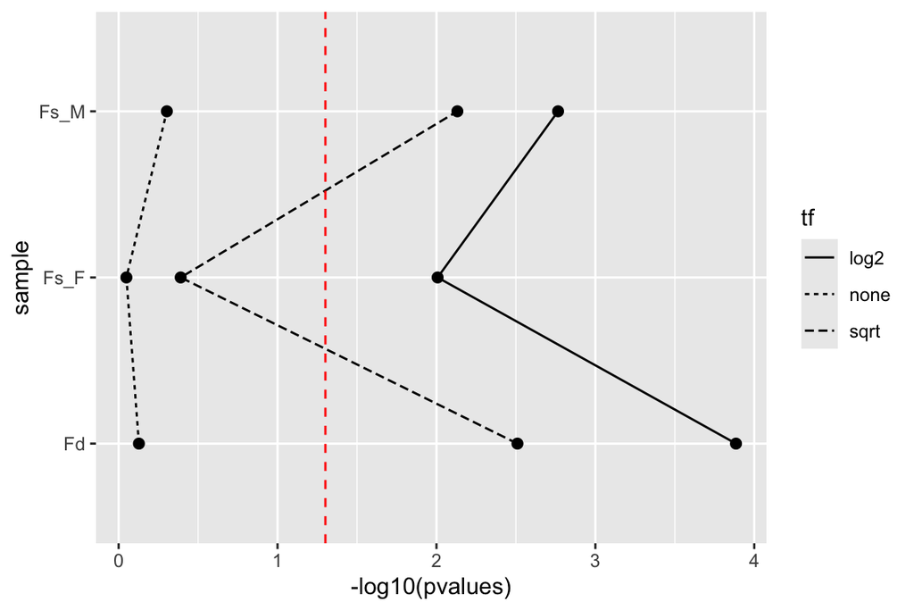

```r
p_res <- data.frame(
        pvalues = c(Fd_pairwisetest, Fs_M_pairwisetest, Fs_F_pairwisetest,
          Fd_pairwisetest.sqrt, Fs_M_pairwisetest.sqrt, Fs_F_pairwisetest.sqrt,
          Fd_pairwisetest.log2, Fs_M_pairwisetest.log2, Fs_F_pairwisetest.log2),
        species = c("Fd", "Fs", "Fs", "Fd", "Fs", "Fs", "Fd", "Fs", "Fs"),
        sex = c("mixed", "M", "F", "mixed", "M", "F", "mixed", "M", "F"),
        tf = c("none", "none", "none",
                           "sqrt", "sqrt", "sqrt",
                           "log2", "log2", "log2"),
        sample = c("Fd", "Fs_M", "Fs_F", "Fd", "Fs_M", "Fs_F", "Fd", "Fs_M", "Fs_F")
)

p_res |>
        ggplot2::ggplot(aes(x = sample, y = -log10(pvalues), linetype = tf, group = tf)) +
        ggplot2::geom_line() +
        ggplot2::geom_point(size = 2) +
        ggplot2::geom_hline(yintercept = -log10(0.05), colour = "red", linetype = 2) +
        ggplot2::coord_flip()
```

```r
p_res
```

| pvalues | species | sex | tf | sample |
| --- | --- | --- | --- | --- |
| 0.7455435025 | Fd | mixed | none | Fd |
| 0.4972632172 | Fs | M | none | Fs_M |
| 0.8935945400 | Fs | F | none | Fs_F |
| 0.0030931201 | Fd | mixed | sqrt | Fd |
| 0.0073855964 | Fs | M | sqrt | Fs_M |
| 0.4070371462 | Fs | F | sqrt | Fs_F |
| 0.0001303537 | Fd | mixed | log2 | Fd |
| 0.0017166252 | Fs | M | log2 | Fs_M |
| 0.0098340517 | Fs | F | log2 | Fs_F |

## `FlatLineTest()` for matSP tissues

non-tranformed

```r
Fd_FLT <-
        myTAI::FlatLineTest(
                ExpressionSet = Fd_PES_matSP,
                permutations = 1000)$p.value
```

```
##
## [ Number of Eigen threads that are employed on your machine: 8 ]
##
## [ Computing age assignment permutations for test statistic ... ]
## [=========================================] 100%
## [ Computing variances of permuted transcriptome signatures ... ]
##
##
## Total runtime of your permutation test: 0.111  seconds.
```

```r
Fs_F_FLT <-
        myTAI::FlatLineTest(
                ExpressionSet = Fs_PES_F_matSP,
                permutations = 1000)$p.value
```

```
##
## [ Number of Eigen threads that are employed on your machine: 8 ]
##
## [ Computing age assignment permutations for test statistic ... ]
## [=========================================] 100%
## [ Computing variances of permuted transcriptome signatures ... ]
##
##
## Total runtime of your permutation test: 0.123  seconds.
```

```r
Fs_M_FLT <-
        myTAI::FlatLineTest(
                ExpressionSet = Fs_PES_M_matSP,
                permutations = 1000)$p.value
```

```
##
## [ Number of Eigen threads that are employed on your machine: 8 ]
##
## [ Computing age assignment permutations for test statistic ... ]
## [=========================================] 100%
## [ Computing variances of permuted transcriptome signatures ... ]
##
##
## Total runtime of your permutation test: 0.126  seconds.
```

sqrt-tranformed

```r
Fd_FLT.sqrt <-
        myTAI::FlatLineTest(
                ExpressionSet = Fd_PES_matSP.sqrt,
                permutations = 1000)$p.value
```

```
##
## [ Number of Eigen threads that are employed on your machine: 8 ]
##
## [ Computing age assignment permutations for test statistic ... ]
## [=========================================] 100%
## [ Computing variances of permuted transcriptome signatures ... ]
##
##
## Total runtime of your permutation test: 0.13  seconds.
```

```r
Fs_F_FLT.sqrt <-
        myTAI::FlatLineTest(
                ExpressionSet = Fs_PES_F_matSP.sqrt,
                permutations = 1000)$p.value
```

```
##
## [ Number of Eigen threads that are employed on your machine: 8 ]
##
## [ Computing age assignment permutations for test statistic ... ]
## [=========================================] 100%
## [ Computing variances of permuted transcriptome signatures ... ]
##
##
## Total runtime of your permutation test: 0.134  seconds.
```

```r
Fs_M_FLT.sqrt <-
        myTAI::FlatLineTest(
                ExpressionSet = Fs_PES_M_matSP.sqrt,
                permutations = 1000)$p.value
```

```
##
## [ Number of Eigen threads that are employed on your machine: 8 ]
##
## [ Computing age assignment permutations for test statistic ... ]
## [=========================================] 100%
## [ Computing variances of permuted transcriptome signatures ... ]
##
##
## Total runtime of your permutation test: 0.123  seconds.
```

log2-tranformed

```r
Fd_FLT.log2 <-
        myTAI::FlatLineTest(
                ExpressionSet = Fd_PES_matSP.log2,
                permutations = 1000)$p.value
```

```
##
## [ Number of Eigen threads that are employed on your machine: 8 ]
##
## [ Computing age assignment permutations for test statistic ... ]
## [=========================================] 100%
## [ Computing variances of permuted transcriptome signatures ... ]
##
##
## Total runtime of your permutation test: 0.123  seconds.
```

```r
Fs_F_FLT.log2 <-
        myTAI::FlatLineTest(
                ExpressionSet = Fs_PES_F_matSP.log2,
                permutations = 1000)$p.value
```

```
##
## [ Number of Eigen threads that are employed on your machine: 8 ]
##
## [ Computing age assignment permutations for test statistic ... ]
## [=========================================] 100%
## [ Computing variances of permuted transcriptome signatures ... ]
##
##
## Total runtime of your permutation test: 0.125  seconds.
```

```r
Fs_M_FLT.log2 <-
        myTAI::FlatLineTest(
                ExpressionSet = Fs_PES_M_matSP.log2,
                permutations = 1000)$p.value
```

```
##
## [ Number of Eigen threads that are employed on your machine: 8 ]
##
## [ Computing age assignment permutations for test statistic ... ]
## [=========================================] 100%
## [ Computing variances of permuted transcriptome signatures ... ]
##
##
## Total runtime of your permutation test: 0.131  seconds.
```

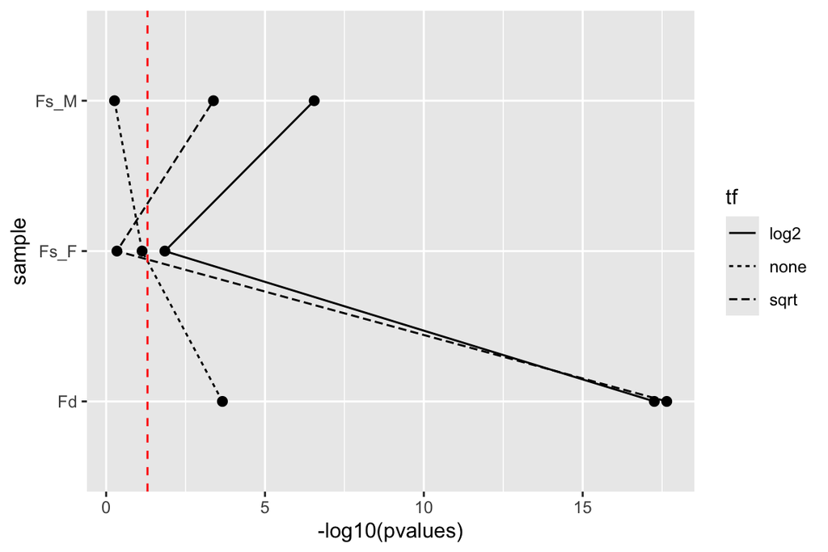

```r
p_res <- data.frame(
        pvalues = c(Fd_FLT, Fs_M_FLT, Fs_F_FLT,
          Fd_FLT.sqrt, Fs_M_FLT.sqrt, Fs_F_FLT.sqrt,
          Fd_FLT.log2, Fs_M_FLT.log2, Fs_F_FLT.log2),
        species = c("Fd", "Fs", "Fs", "Fd", "Fs", "Fs", "Fd", "Fs", "Fs"),
        sex = c("mixed", "M", "F", "mixed", "M", "F", "mixed", "M", "F"),
        tf = c("none", "none", "none",
               "sqrt", "sqrt", "sqrt",
               "log2", "log2", "log2"),
        sample = c("Fd", "Fs_M", "Fs_F",
                   "Fd", "Fs_M", "Fs_F",
                   "Fd", "Fs_M", "Fs_F")
)

p_res |>
        ggplot2::ggplot(aes(x = sample, y = -log10(pvalues), linetype = tf, group = tf)) +
        ggplot2::geom_line() +
        ggplot2::geom_point(size = 2) +
        ggplot2::geom_hline(yintercept = -log10(0.05), colour = "red", linetype = 2) +
        ggplot2::coord_flip()
```

```r
p_res
```

| pvalues | species | sex | tf | sample |
| --- | --- | --- | --- | --- |
| 2.192248e-04 | Fd | mixed | none | Fd |
| 5.460770e-01 | Fs | M | none | Fs_M |
| 7.394328e-02 | Fs | F | none | Fs_F |
| 2.264073e-18 | Fd | mixed | sqrt | Fd |
| 4.203321e-04 | Fs | M | sqrt | Fs_M |
| 4.582207e-01 | Fs | F | sqrt | Fs_F |
| 5.573940e-18 | Fd | mixed | log2 | Fd |
| 2.827617e-07 | Fs | M | log2 | Fs_M |
| 1.417845e-02 | Fs | F | log2 | Fs_F |

## `PairwiseTest()` for matSP reptip male vs female

non-tranformed

```r
Fs_PES_reptip <-
        dplyr::full_join(
        Fs_PES_M_matSP,
        Fs_PES_F_matSP,
        by = c("PS", "GeneID"),
        suffix = c(".M", ".F")) |>
        dplyr::select(!dplyr::contains(c("holdfast", "stipe", "vegtip")))

Fs_rt_pairwisetest <-
        myTAI::PairwiseTest(
                ExpressionSet = Fs_PES_reptip,
                modules = list(contrast1 = 1, contrast2 = 2),
                altHypothesis = "greater",
                permutations = 1000)$p.value
```

```
##
## [ Number of Eigen threads that are employed on your machine: 8 ]
##
## [ Computing age assignment permutations for test statistic ... ]
## [=========================================] 100%
## [ Computing variances of permuted transcriptome signatures ... ]
```

sqrt-tranformed

```r
Fs_PES_reptip.sqrt <-
        dplyr::full_join(
        Fs_PES_M_matSP.sqrt,
        Fs_PES_F_matSP.sqrt,
        by = c("PS", "GeneID"),
        suffix = c(".M", ".F")) |>
        dplyr::select(!dplyr::contains(c("holdfast", "stipe", "vegtip")))

Fs_rt_pairwisetest.sqrt <-
        myTAI::PairwiseTest(
                ExpressionSet = Fs_PES_reptip.sqrt,
                modules = list(contrast1 = 1, contrast2 = 2),
                altHypothesis = "greater",
                permutations = 1000)$p.value
```

```
##
## [ Number of Eigen threads that are employed on your machine: 8 ]
##
## [ Computing age assignment permutations for test statistic ... ]
## [=========================================] 100%
## [ Computing variances of permuted transcriptome signatures ... ]
```

log2-tranformed

```r
Fs_PES_reptip.log2 <-
        dplyr::full_join(
        Fs_PES_M_matSP.log2,
        Fs_PES_F_matSP.log2,
        by = c("PS", "GeneID"),
        suffix = c(".M", ".F")) |>
        dplyr::select(!dplyr::contains(c("holdfast", "stipe", "vegtip")))

Fs_rt_pairwisetest.log2 <-
        myTAI::PairwiseTest(
                ExpressionSet = Fs_PES_reptip.log2,
                modules = list(contrast1 = 1, contrast2 = 2),
                altHypothesis = "greater",
                permutations = 1000)$p.value
```

```
##
## [ Number of Eigen threads that are employed on your machine: 8 ]
##
## [ Computing age assignment permutations for test statistic ... ]
## [=========================================] 100%
## [ Computing variances of permuted transcriptome signatures ... ]
```

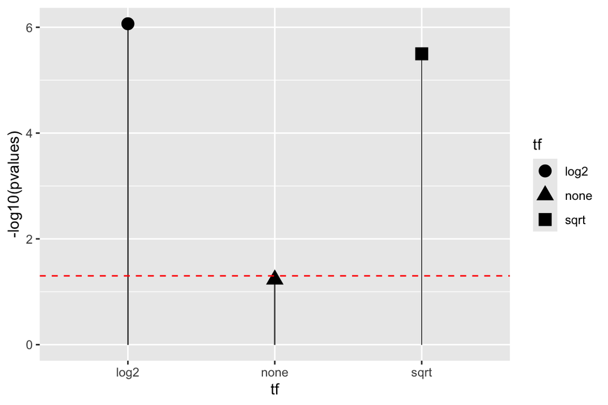

```r
p_res <- data.frame(
        pvalues = c(Fs_rt_pairwisetest, Fs_rt_pairwisetest.sqrt, Fs_rt_pairwisetest.log2),
        species = c("Fs", "Fs", "Fs"),
        tf = c("none", "sqrt", "log2"),
        sample = c("Fs", "Fs", "Fs")
)

p_res |>
        ggplot2::ggplot(aes(x = tf, y = -log10(pvalues), group = 1, shape = tf)) +
        ggplot2::geom_col(width = 0.01) +
        ggplot2::geom_point(size = 4) +
        ggplot2::geom_hline(yintercept = -log10(0.05), colour = "red", linetype = 2) +
        ggplot2::ylim(0, -log10(min(p_res$pvalues)))
```

```r
p_res
```

| pvalues | species | tf | sample |
| --- | --- | --- | --- |
| 5.857342e-02 | Fs | none | Fs |
| 3.173565e-06 | Fs | sqrt | Fs |
| 8.572464e-07 | Fs | log2 | Fs |

## `PairwiseTest()` for matSP vegetative tissues (vegtip, holdfast, stipe) male vs female

Here I focus on showing all the tissue comparisons.

sqrt-tranformed

```r
Fs_PES_vegtip.sqrt <-
        dplyr::full_join(
        Fs_PES_M_matSP.sqrt,
        Fs_PES_F_matSP.sqrt,
        by = c("PS", "GeneID"),
        suffix = c(".M", ".F")) |>
        dplyr::select(!dplyr::contains(c("holdfast", "stipe", "reptip")))

Fs_rt_pairwisetest.vegtip.sqrt <-
        myTAI::PairwiseTest(
                ExpressionSet = Fs_PES_vegtip.sqrt,
                modules = list(contrast1 = 1, contrast2 = 2),
                altHypothesis = "greater",
                permutations = 1000)$p.value
```

```
##
## [ Number of Eigen threads that are employed on your machine: 8 ]
##
## [ Computing age assignment permutations for test statistic ... ]
## [=========================================] 100%
## [ Computing variances of permuted transcriptome signatures ... ]
```

```r
Fs_PES_stipe.sqrt <-
        dplyr::full_join(
        Fs_PES_M_matSP.sqrt,
        Fs_PES_F_matSP.sqrt,
        by = c("PS", "GeneID"),
        suffix = c(".M", ".F")) |>
        dplyr::select(!dplyr::contains(c("holdfast", "vegtip", "reptip")))

Fs_rt_pairwisetest.stipe.sqrt <-
        myTAI::PairwiseTest(
                ExpressionSet = Fs_PES_stipe.sqrt,
                modules = list(contrast1 = 1, contrast2 = 2),
                altHypothesis = "greater",
                permutations = 1000)$p.value
```

```
##
## [ Number of Eigen threads that are employed on your machine: 8 ]
##
## [ Computing age assignment permutations for test statistic ... ]
## [=========================================] 100%
## [ Computing variances of permuted transcriptome signatures ... ]
```

```r
Fs_PES_holdfast.sqrt <-
        dplyr::full_join(
        Fs_PES_M_matSP.sqrt,
        Fs_PES_F_matSP.sqrt,
        by = c("PS", "GeneID"),
        suffix = c(".M", ".F")) |>
        dplyr::select(!dplyr::contains(c("stipe", "vegtip", "reptip")))

Fs_rt_pairwisetest.holdfast.sqrt <-
        myTAI::PairwiseTest(
                ExpressionSet = Fs_PES_holdfast.sqrt,
                modules = list(contrast1 = 1, contrast2 = 2),
                altHypothesis = "greater",
                permutations = 1000)$p.value
```

```
##
## [ Number of Eigen threads that are employed on your machine: 8 ]
##
## [ Computing age assignment permutations for test statistic ... ]
## [=========================================] 100%
## [ Computing variances of permuted transcriptome signatures ... ]
```

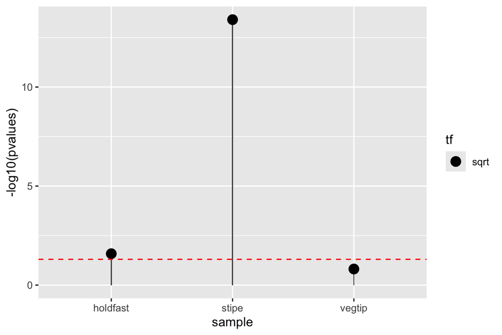

```r
p_res <- data.frame(
        pvalues = c(
                Fs_rt_pairwisetest.vegtip.sqrt,
                Fs_rt_pairwisetest.stipe.sqrt,
                Fs_rt_pairwisetest.holdfast.sqrt),
        species = c("Fs", "Fs", "Fs"),
        tf = c("sqrt", "sqrt", "sqrt"),
        sample = c("vegtip", "stipe", "holdfast")
)

p_res |>
        ggplot2::ggplot(aes(x = sample, y = -log10(pvalues), group = 1, shape = tf)) +
        ggplot2::geom_col(width = 0.01) +
        ggplot2::geom_point(size = 4) +
        ggplot2::geom_hline(yintercept = -log10(0.05), colour = "red", linetype = 2) +
        ggplot2::ylim(0, -log10(min(p_res$pvalues)))
```

```r
p_res
```

| pvalues | species | tf | sample |
| --- | --- | --- | --- |
| 1.539801e-01 | Fs | sqrt | vegtip |
| 3.951654e-14 | Fs | sqrt | stipe |
| 2.597346e-02 | Fs | sqrt | holdfast |

## `PairwiseTest()` for matSP gamete male vs female

### Load PES

non-transformed

```r
Fd_PES_M <-
  readr::read_csv(file = "data/Fd_PES_M.csv", show_col_types = FALSE)
Fd_PES_F <-
  readr::read_csv(file = "data/Fd_PES_F.csv", show_col_types = FALSE)
Fs_PES_M <-
  readr::read_csv(file = "data/Fs_PES_M.csv", show_col_types = FALSE) |> dplyr::select(-matSP)
Fs_PES_F <-
  readr::read_csv(file = "data/Fs_PES_F.csv", show_col_types = FALSE) |> dplyr::select(-matSP)
Fd_PES_gamete <-
        dplyr::full_join(
                Fd_PES_M, Fd_PES_F,
                by = c("PS", "GeneID"),
                suffix = c(".M", ".F"))
Fs_PES_gamete <-
        dplyr::full_join(
                Fs_PES_M, Fs_PES_F,
                by = c("PS", "GeneID"),
                suffix = c(".M", ".F"))
```

sqrt-tranformed

```r
Fd_PES_M.sqrt <-
  readr::read_csv(file = "data/Fd_PES_M.sqrt.csv", show_col_types = FALSE) |> dplyr::rename(gamete = V1)
Fd_PES_F.sqrt <-
  readr::read_csv(file = "data/Fd_PES_F.sqrt.csv", show_col_types = FALSE) |> dplyr::rename(gamete = V1)
Fs_PES_M.sqrt <-
  readr::read_csv(file = "data/Fs_PES_M.sqrt.csv", show_col_types = FALSE) |> dplyr::select(-matSP)
Fs_PES_F.sqrt <-
  readr::read_csv(file = "data/Fs_PES_F.sqrt.csv", show_col_types = FALSE) |> dplyr::select(-matSP)
Fd_PES_gamete.sqrt <-
        dplyr::full_join(
                Fd_PES_M.sqrt, Fd_PES_F.sqrt,
                by = c("PS", "GeneID"),
                suffix = c(".M", ".F"))
Fs_PES_gamete.sqrt <-
        dplyr::full_join(
                Fs_PES_M.sqrt, Fs_PES_F.sqrt,
                by = c("PS", "GeneID"),
                suffix = c(".M", ".F"))
```

log2-tranformed

```r
Fd_PES_M.log2 <-
  readr::read_csv(file = "data/Fd_PES_M.log2.csv", show_col_types = FALSE) |> dplyr::rename(gamete = V1)
Fd_PES_F.log2 <-
  readr::read_csv(file = "data/Fd_PES_F.log2.csv", show_col_types = FALSE) |> dplyr::rename(gamete = V1)
Fs_PES_M.log2 <-
  readr::read_csv(file = "data/Fs_PES_M.log2.csv", show_col_types = FALSE) |> dplyr::select(-matSP)
Fs_PES_F.log2 <-
  readr::read_csv(file = "data/Fs_PES_F.log2.csv", show_col_types = FALSE) |> dplyr::select(-matSP)

Fd_PES_gamete.log2 <-
        dplyr::full_join(
                Fd_PES_M.log2, Fd_PES_F.log2,
                by = c("PS", "GeneID"),
                suffix = c(".M", ".F"))
Fs_PES_gamete.log2 <-
        dplyr::full_join(
                Fs_PES_M.log2, Fs_PES_F.log2,
                by = c("PS", "GeneID"),
                suffix = c(".M", ".F"))
```

non-tranformed

```r
Fd_gam_pairwisetest <-
        myTAI::PairwiseTest(
                ExpressionSet = Fd_PES_gamete,
                modules = list(contrast1 = 1, contrast2 = 2),
                altHypothesis = "greater",
                permutations = 1000)$p.value
```

```
##
## [ Number of Eigen threads that are employed on your machine: 8 ]
##
## [ Computing age assignment permutations for test statistic ... ]
## [=========================================] 100%
## [ Computing variances of permuted transcriptome signatures ... ]
```

```r
Fs_gam_pairwisetest <-
        myTAI::PairwiseTest(
                ExpressionSet = Fs_PES_gamete,
                modules = list(contrast1 = 1, contrast2 = 2),
                altHypothesis = "greater",
                permutations = 1000)$p.value
```

```
##
## [ Number of Eigen threads that are employed on your machine: 8 ]
##
## [ Computing age assignment permutations for test statistic ... ]
## [=========================================] 100%
## [ Computing variances of permuted transcriptome signatures ... ]
```

sqrt-tranformed

```r
Fd_gam_pairwisetest.sqrt <-
        myTAI::PairwiseTest(
                ExpressionSet = Fd_PES_gamete.sqrt,
                modules = list(contrast1 = 1, contrast2 = 2),
                altHypothesis = "greater",
                permutations = 1000)$p.value
```

```
##
## [ Number of Eigen threads that are employed on your machine: 8 ]
##
## [ Computing age assignment permutations for test statistic ... ]
## [=========================================] 100%
## [ Computing variances of permuted transcriptome signatures ... ]
```

```r
Fs_gam_pairwisetest.sqrt <-
        myTAI::PairwiseTest(
                ExpressionSet = Fs_PES_gamete.sqrt,
                modules = list(contrast1 = 1, contrast2 = 2),
                altHypothesis = "greater",
                permutations = 1000)$p.value
```

```
##
## [ Number of Eigen threads that are employed on your machine: 8 ]
##
## [ Computing age assignment permutations for test statistic ... ]
## [=========================================] 100%
## [ Computing variances of permuted transcriptome signatures ... ]
```

log2-tranformed

```r
Fd_gam_pairwisetest.log2 <-
        myTAI::PairwiseTest(
                ExpressionSet = Fd_PES_gamete.log2,
                modules = list(contrast1 = 1, contrast2 = 2),
                altHypothesis = "greater",
                permutations = 1000)$p.value
```

```
##
## [ Number of Eigen threads that are employed on your machine: 8 ]
##
## [ Computing age assignment permutations for test statistic ... ]
## [=========================================] 100%
## [ Computing variances of permuted transcriptome signatures ... ]
```

```r
Fs_gam_pairwisetest.log2 <-
        myTAI::PairwiseTest(
                ExpressionSet = Fs_PES_gamete.log2,
                modules = list(contrast1 = 1, contrast2 = 2),
                altHypothesis = "greater",
                permutations = 1000)$p.value
```

```
##
## [ Number of Eigen threads that are employed on your machine: 8 ]
##
## [ Computing age assignment permutations for test statistic ... ]
## [=========================================] 100%
## [ Computing variances of permuted transcriptome signatures ... ]
```

```r
p_res <- data.frame(
        pvalues = c(Fd_gam_pairwisetest, Fs_gam_pairwisetest,
          Fd_gam_pairwisetest.sqrt, Fs_gam_pairwisetest.sqrt,
          Fd_gam_pairwisetest.log2, Fs_gam_pairwisetest.log2),
        species = c("Fd", "Fs", "Fd", "Fs", "Fd", "Fs"),
        tf = c("none", "none", "sqrt", "sqrt", "log2", "log2")
)
```

```r
p_res
```

| pvalues | species | tf |
| --- | --- | --- |
| 0.2164044 | Fd | none |
| 0.5839831 | Fs | none |
| 0.1810382 | Fd | sqrt |
| 0.1876075 | Fs | sqrt |
| 0.9963144 | Fd | log2 |
| 0.4617165 | Fs | log2 |

Male gametes are not significantly younger than females. I suspect that this is because the variance in the TAI values are generally higher in the gametes.

## `PairwiseTest()` for matSP gamete vs all (excluding reptip)

We ask whether the gamete is generally younger than the vegetative tissues in general.

### Combine PES

```r
Fs_PES_M_matSPG <-
        Fs_PES_M_matSP |>
        dplyr::left_join(Fs_PES_M)
Fs_PES_M_matSPG.sqrt <-
        Fs_PES_M_matSP.sqrt |>
        dplyr::left_join(Fs_PES_M.sqrt)
Fs_PES_M_matSPG.log2 <-
        Fs_PES_M_matSP.log2 |>
        dplyr::left_join(Fs_PES_M.log2)

Fs_PES_F_matSPG <-
        Fs_PES_F_matSP |>
        dplyr::left_join(Fs_PES_F)
Fs_PES_F_matSPG.sqrt <-
        Fs_PES_F_matSP.sqrt |>
        dplyr::left_join(Fs_PES_F.sqrt)
Fs_PES_F_matSPG.log2 <-
        Fs_PES_F_matSP.log2 |>
        dplyr::left_join(Fs_PES_F.log2)

# slightly different column name formats.

Fd_PES_matSPG <-
        Fd_PES_matSP |>
        dplyr::left_join(Fd_PES_gamete)
Fd_PES_matSPG.sqrt <-
        Fd_PES_matSP.sqrt |>
        dplyr::left_join(Fd_PES_gamete.sqrt)
Fd_PES_matSPG.log2 <-
        Fd_PES_matSP.log2 |>
        dplyr::left_join(Fd_PES_gamete.log2)
```

non-tranformed

```r
Fd_F_pairwisetest <-
        myTAI::PairwiseTest(
                ExpressionSet = Fd_PES_matSPG,
                modules = list(contrast1 = 6, contrast2 = c(1,3,4)),
                altHypothesis = "greater",
                permutations = 1000)$p.value
```

```
##
## [ Number of Eigen threads that are employed on your machine: 8 ]
##
## [ Computing age assignment permutations for test statistic ... ]
## [=========================================] 100%
## [ Computing variances of permuted transcriptome signatures ... ]
```

```r
Fd_M_pairwisetest <-
        myTAI::PairwiseTest(
                ExpressionSet = Fd_PES_matSPG,
                modules = list(contrast1 = 5, contrast2 = c(1,3,4)),
                altHypothesis = "greater",
                permutations = 1000)$p.value
```

```
##
## [ Number of Eigen threads that are employed on your machine: 8 ]
##
## [ Computing age assignment permutations for test statistic ... ]
## [=========================================] 100%
## [ Computing variances of permuted transcriptome signatures ... ]
```

```r
Fs_F_pairwisetest <-
        myTAI::PairwiseTest(
                ExpressionSet = Fs_PES_F_matSPG,
                modules = list(contrast1 = 5, contrast2 = c(1,3,4)),
                altHypothesis = "greater",
                permutations = 1000)$p.value
```

```
##
## [ Number of Eigen threads that are employed on your machine: 8 ]
##
## [ Computing age assignment permutations for test statistic ... ]
## [=========================================] 100%
## [ Computing variances of permuted transcriptome signatures ... ]
```

```r
Fs_M_pairwisetest <-
        myTAI::PairwiseTest(
                ExpressionSet = Fs_PES_M_matSPG,
                modules = list(contrast1 = 5, contrast2 = c(1,3,4)),
                altHypothesis = "greater",
                permutations = 1000)$p.value
```

```
##
## [ Number of Eigen threads that are employed on your machine: 8 ]
##
## [ Computing age assignment permutations for test statistic ... ]
## [=========================================] 100%
## [ Computing variances of permuted transcriptome signatures ... ]
```

sqrt-tranformed

```r
Fd_F_pairwisetest.sqrt <-
        myTAI::PairwiseTest(
                ExpressionSet = Fd_PES_matSPG.sqrt,
                modules = list(contrast1 = 6, contrast2 = c(1,3,4)),
                altHypothesis = "greater",
                permutations = 1000)$p.value
```

```
##
## [ Number of Eigen threads that are employed on your machine: 8 ]
##
## [ Computing age assignment permutations for test statistic ... ]
## [=========================================] 100%
## [ Computing variances of permuted transcriptome signatures ... ]
```

```r
Fd_M_pairwisetest.sqrt <-
        myTAI::PairwiseTest(
                ExpressionSet = Fd_PES_matSPG.sqrt,
                modules = list(contrast1 = 5, contrast2 = c(1,3,4)),
                altHypothesis = "greater",
                permutations = 1000)$p.value
```

```
##
## [ Number of Eigen threads that are employed on your machine: 8 ]
##
## [ Computing age assignment permutations for test statistic ... ]
## [=========================================] 100%
## [ Computing variances of permuted transcriptome signatures ... ]
```

```r
Fs_F_pairwisetest.sqrt <-
        myTAI::PairwiseTest(
                ExpressionSet = Fs_PES_F_matSPG.sqrt,
                modules = list(contrast1 = 5, contrast2 = c(1,3,4)),
                altHypothesis = "greater",
                permutations = 1000)$p.value
```

```
##
## [ Number of Eigen threads that are employed on your machine: 8 ]
##
## [ Computing age assignment permutations for test statistic ... ]
## [=========================================] 100%
## [ Computing variances of permuted transcriptome signatures ... ]
```

```r
Fs_M_pairwisetest.sqrt <-
        myTAI::PairwiseTest(
                ExpressionSet = Fs_PES_M_matSPG.sqrt,
                modules = list(contrast1 = 5, contrast2 = c(1,3,4)),
                altHypothesis = "greater",
                permutations = 1000)$p.value
```

```
##
## [ Number of Eigen threads that are employed on your machine: 8 ]
##
## [ Computing age assignment permutations for test statistic ... ]
## [=========================================] 100%
## [ Computing variances of permuted transcriptome signatures ... ]
```

log2-tranformed

```r
Fd_F_pairwisetest.log2 <-
        myTAI::PairwiseTest(
                ExpressionSet = Fd_PES_matSPG.log2,
                modules = list(contrast1 = 6, contrast2 = c(1,3,4)),
                altHypothesis = "greater",
                permutations = 1000)$p.value
```

```
##
## [ Number of Eigen threads that are employed on your machine: 8 ]
##
## [ Computing age assignment permutations for test statistic ... ]
## [=========================================] 100%
## [ Computing variances of permuted transcriptome signatures ... ]
```

```r
Fd_M_pairwisetest.log2 <-
        myTAI::PairwiseTest(
                ExpressionSet = Fd_PES_matSPG.log2,
                modules = list(contrast1 = 5, contrast2 = c(1,3,4)),
                altHypothesis = "greater",
                permutations = 1000)$p.value
```

```
##
## [ Number of Eigen threads that are employed on your machine: 8 ]
##
## [ Computing age assignment permutations for test statistic ... ]
## [=========================================] 100%
## [ Computing variances of permuted transcriptome signatures ... ]
```

```r
Fs_F_pairwisetest.log2 <-
        myTAI::PairwiseTest(
                ExpressionSet = Fs_PES_F_matSPG.log2,
                modules = list(contrast1 = 5, contrast2 = c(1,3,4)),
                altHypothesis = "greater",
                permutations = 1000)$p.value
```

```
##
## [ Number of Eigen threads that are employed on your machine: 8 ]
##
## [ Computing age assignment permutations for test statistic ... ]
## [=========================================] 100%
## [ Computing variances of permuted transcriptome signatures ... ]
```

```r
Fs_M_pairwisetest.log2 <-
        myTAI::PairwiseTest(
                ExpressionSet = Fs_PES_M_matSPG.log2,
                modules = list(contrast1 = 5, contrast2 = c(1,3,4)),
                altHypothesis = "greater",
                permutations = 1000)$p.value
```

```
##
## [ Number of Eigen threads that are employed on your machine: 8 ]
##
## [ Computing age assignment permutations for test statistic ... ]
## [=========================================] 100%
## [ Computing variances of permuted transcriptome signatures ... ]
```

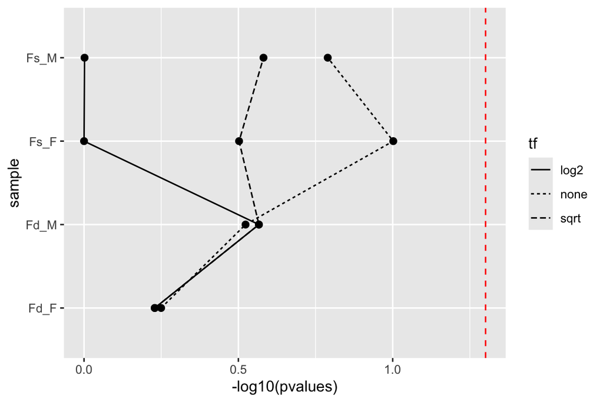

```r
p_res <- data.frame(
        pvalues = c(Fd_M_pairwisetest, Fd_F_pairwisetest, Fs_M_pairwisetest, Fs_F_pairwisetest,
          Fd_M_pairwisetest.sqrt, Fd_F_pairwisetest.sqrt, Fs_M_pairwisetest.sqrt, Fs_F_pairwisetest.sqrt,
          Fd_M_pairwisetest.sqrt, Fd_F_pairwisetest.sqrt, Fs_M_pairwisetest.log2, Fs_F_pairwisetest.log2),
        species = c("Fd", "Fd", "Fs", "Fs", "Fd", "Fd", "Fs", "Fs", "Fd", "Fd", "Fs", "Fs"),
        sex = c("M", "F", "M", "F", "M", "F", "M", "F", "M", "F", "M", "F"),
        tf = c("none", "none", "none", "none",
                           "sqrt", "sqrt", "sqrt", "sqrt",
                           "log2", "log2", "log2", "log2"),
        sample = c("Fd_M", "Fd_F", "Fs_M", "Fs_F", "Fd_M", "Fd_F", "Fs_M", "Fs_F", "Fd_M", "Fd_F", "Fs_M", "Fs_F")
)

p_res |>
        ggplot2::ggplot(aes(x = sample, y = -log10(pvalues), linetype = tf, group = tf)) +
        ggplot2::geom_line() +
        ggplot2::geom_point(size = 2) +
        ggplot2::geom_hline(yintercept = -log10(0.05), colour = "red", linetype = 2) +
        ggplot2::coord_flip()
```

```r
p_res
```

| pvalues | species | sex | tf | sample |
| --- | --- | --- | --- | --- |
| 0.29975260 | Fd | M | none | Fd_M |
| 0.56276856 | Fd | F | none | Fd_F |
| 0.16234231 | Fs | M | none | Fs_M |
| 0.09956013 | Fs | F | none | Fs_F |
| 0.27129061 | Fd | M | sqrt | Fd_M |
| 0.59007037 | Fd | F | sqrt | Fd_F |
| 0.26219638 | Fs | M | sqrt | Fs_M |
| 0.31455140 | Fs | F | sqrt | Fs_F |
| 0.27129061 | Fd | M | log2 | Fd_M |
| 0.59007037 | Fd | F | log2 | Fd_F |

[output cut: 2 more lines]

At the gamete level, the difference in TAI is not significant, partly due to the high variance in the TAI value from the gametes.

# Further stats for evolutionary transcriptome pattern in *Ectocarpus*

Here, we examine whether the significance in the difference between the TAI in *Ectocarpus* unicellular stages vs multicellular stages.

```r
library(tidyverse)
library(myTAI)
```

### Load PES

non-transformed

```r
Ec_PES_M <-
  readr::read_csv(file = "data/Ec_PES_32m.csv", show_col_types = FALSE)
Ec_PES_F <-
  readr::read_csv(file = "data/Ec_PES_25f.csv", show_col_types = FALSE)
```

sqrt-tranformed

```r
Ec_PES_M.sqrt <-
  readr::read_csv(file = "data/Ec_PES_32m.sqrt.csv", show_col_types = FALSE)
Ec_PES_F.sqrt <-
  readr::read_csv(file = "data/Ec_PES_25f.sqrt.csv", show_col_types = FALSE)
```

log2-tranformed

```r
Ec_PES_M.log2 <-
  readr::read_csv(file = "data/Ec_PES_32m.log2.csv", show_col_types = FALSE)
Ec_PES_F.log2 <-
  readr::read_csv(file = "data/Ec_PES_25f.log2.csv", show_col_types = FALSE)
```

## `PairwiseTest()` for unicell vs multicell TAI

col 1, 5 and 9 are unicells.

```r
Ec_M_pairwisetest <-
        myTAI::PairwiseTest(Ec_PES_M, modules = list(contrast1 = c(1,5,9), contrast2 = c(2,3,4,6,7,8)), altHypothesis = "greater", permutations = 1000)$p.value
```

```
##
## [ Number of Eigen threads that are employed on your machine: 8 ]
##
## [ Computing age assignment permutations for test statistic ... ]
## [=========================================] 100%
## [ Computing variances of permuted transcriptome signatures ... ]
```

```r
Ec_F_pairwisetest <-
        myTAI::PairwiseTest(Ec_PES_F, modules = list(contrast1 = c(1,5,9), contrast2 = c(2,3,4,6,7,8)), altHypothesis = "greater", permutations = 1000)$p.value
```

```
##
## [ Number of Eigen threads that are employed on your machine: 8 ]
##
## [ Computing age assignment permutations for test statistic ... ]
## [=========================================] 100%
## [ Computing variances of permuted transcriptome signatures ... ]
```

```r
Ec_M_pairwisetest.sqrt <-
        myTAI::PairwiseTest(Ec_PES_M.sqrt, modules = list(contrast1 = c(1,5,9), contrast2 = c(2,3,4,6,7,8)), altHypothesis = "greater", permutations = 1000)$p.value
```

```
##
## [ Number of Eigen threads that are employed on your machine: 8 ]
##
## [ Computing age assignment permutations for test statistic ... ]
## [=========================================] 100%
## [ Computing variances of permuted transcriptome signatures ... ]
```

```r
Ec_F_pairwisetest.sqrt <-
        myTAI::PairwiseTest(Ec_PES_F.sqrt, modules = list(contrast1 = c(1,5,9), contrast2 = c(2,3,4,6,7,8)), altHypothesis = "greater", permutations = 1000)$p.value
```

```
##
## [ Number of Eigen threads that are employed on your machine: 8 ]
##
## [ Computing age assignment permutations for test statistic ... ]
## [=========================================] 100%
## [ Computing variances of permuted transcriptome signatures ... ]
```

```r
Ec_M_pairwisetest.log2 <-
        myTAI::PairwiseTest(Ec_PES_M.log2, modules = list(contrast1 = c(1,5,9), contrast2 = c(2,3,4,6,7,8)), altHypothesis = "greater", permutations = 1000)$p.value
```

```
##
## [ Number of Eigen threads that are employed on your machine: 8 ]
##
## [ Computing age assignment permutations for test statistic ... ]
## [=========================================] 100%
## [ Computing variances of permuted transcriptome signatures ... ]
```

```r
Ec_F_pairwisetest.log2 <-
        myTAI::PairwiseTest(Ec_PES_F.log2, modules = list(contrast1 = c(1,5,9), contrast2 = c(2,3,4,6,7,8)), altHypothesis = "greater", permutations = 1000)$p.value
```

```
##
## [ Number of Eigen threads that are employed on your machine: 8 ]
##
## [ Computing age assignment permutations for test statistic ... ]
## [=========================================] 100%
## [ Computing variances of permuted transcriptome signatures ... ]
```

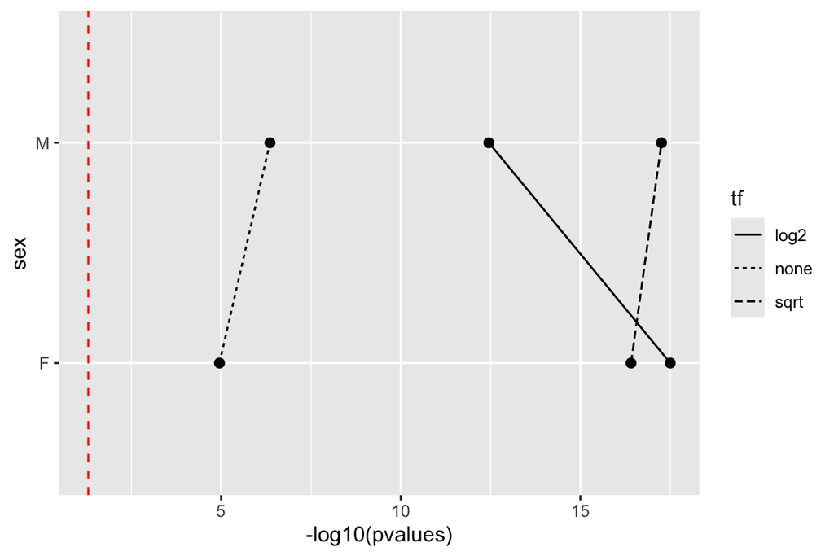

```r
p_res <- data.frame(
        pvalues = c(Ec_M_pairwisetest, Ec_M_pairwisetest.sqrt, Ec_M_pairwisetest.log2,
          Ec_F_pairwisetest, Ec_F_pairwisetest.sqrt, Ec_F_pairwisetest.log2),
        sex = c("M", "M", "M", "F", "F", "F"),
        tf = c("none", "sqrt", "log2", "none", "sqrt", "log2")
)

p_res |>
        ggplot2::ggplot(aes(x = sex, y = -log10(pvalues), linetype = tf, group = tf)) +
        ggplot2::geom_line() +
        ggplot2::geom_point(size = 2) +
        ggplot2::geom_hline(yintercept = -log10(0.05), colour = "red", linetype = 2) +
        ggplot2::coord_flip()
```

```r
p_res
```

| pvalues | sex | tf |
| --- | --- | --- |
| 4.375769e-07 | M | none |
| 5.508776e-18 | M | sqrt |
| 3.535805e-13 | M | log2 |
| 1.113829e-05 | F | none |
| 3.887079e-17 | F | sqrt |
| 3.145897e-18 | F | log2 |

Unicells are significantly younger than multicellular stages.

## `ReductiveHourglassTest()` for multicell development

cols 2,3,4 are multicellular GA and 6,7,8 are multicellular PSP.

```r
Ec_PES_M.GA <- Ec_PES_M |> dplyr::select(1,2,c(2,3,4)+2)
Ec_PES_M.PSP <- Ec_PES_M |> dplyr::select(1,2,c(6,7,8)+2)
Ec_PES_F.GA <- Ec_PES_F |> dplyr::select(1,2,c(2,3,4)+2)
Ec_PES_F.PSP <- Ec_PES_F |> dplyr::select(1,2,c(6,7,8)+2)

Ec_PES_M.GA.sqrt <- Ec_PES_M.sqrt |> dplyr::select(1,2,c(2,3,4)+2)
Ec_PES_M.PSP.sqrt <- Ec_PES_M.sqrt |> dplyr::select(1,2,c(6,7,8)+2)
Ec_PES_F.GA.sqrt <- Ec_PES_F.sqrt |> dplyr::select(1,2,c(2,3,4)+2)
Ec_PES_F.PSP.sqrt <- Ec_PES_F.sqrt |> dplyr::select(1,2,c(6,7,8)+2)

Ec_PES_M.GA.log2 <- Ec_PES_M.log2 |> dplyr::select(1,2,c(2,3,4)+2)
Ec_PES_M.PSP.log2 <- Ec_PES_M.log2 |> dplyr::select(1,2,c(6,7,8)+2)
Ec_PES_F.GA.log2 <- Ec_PES_F.log2 |> dplyr::select(1,2,c(2,3,4)+2)
Ec_PES_F.PSP.log2 <- Ec_PES_F.log2 |> dplyr::select(1,2,c(6,7,8)+2)
```

```r
Ec_M_GA_rht <-
        myTAI::ReductiveHourglassTest(Ec_PES_M.GA, modules = list(early = 1, mid = 2, late = 3), permutations = 1000)$p.value
```

```
##
## [ Number of Eigen threads that are employed on your machine: 8 ]
##
## [ Computing age assignment permutations for test statistic ... ]
## [=========================================] 100%
## [ Computing variances of permuted transcriptome signatures ... ]
```

```r
Ec_M_PSP_rht <-
        myTAI::ReductiveHourglassTest(Ec_PES_M.PSP, modules = list(early = 1, mid = 2, late = 3), permutations = 1000)$p.value
```

```
##
## [ Number of Eigen threads that are employed on your machine: 8 ]
##
## [ Computing age assignment permutations for test statistic ... ]
## [=========================================] 100%
## [ Computing variances of permuted transcriptome signatures ... ]
```

```r
Ec_F_GA_rht <-
        myTAI::ReductiveHourglassTest(Ec_PES_F.GA, modules = list(early = 1, mid = 2, late = 3), permutations = 1000)$p.value
```

```
##
## [ Number of Eigen threads that are employed on your machine: 8 ]
##
## [ Computing age assignment permutations for test statistic ... ]
## [=========================================] 100%
## [ Computing variances of permuted transcriptome signatures ... ]
```

```r
Ec_F_PSP_rht <-
        myTAI::ReductiveHourglassTest(Ec_PES_F.PSP, modules = list(early = 1, mid = 2, late = 3), permutations = 1000)$p.value
```

```
##
## [ Number of Eigen threads that are employed on your machine: 8 ]
##
## [ Computing age assignment permutations for test statistic ... ]
## [=========================================] 100%
## [ Computing variances of permuted transcriptome signatures ... ]
```

```r
Ec_M_GA_rht.sqrt <-
        myTAI::ReductiveHourglassTest(Ec_PES_M.GA.sqrt, modules = list(early = 1, mid = 2, late = 3), permutations = 1000)$p.value
```

```
##
## [ Number of Eigen threads that are employed on your machine: 8 ]
##
## [ Computing age assignment permutations for test statistic ... ]
## [=========================================] 100%
## [ Computing variances of permuted transcriptome signatures ... ]
```

```r
Ec_M_PSP_rht.sqrt <-
        myTAI::ReductiveHourglassTest(Ec_PES_M.PSP.sqrt, modules = list(early = 1, mid = 2, late = 3), permutations = 1000)$p.value
```

```
##
## [ Number of Eigen threads that are employed on your machine: 8 ]
##
## [ Computing age assignment permutations for test statistic ... ]
## [=========================================] 100%
## [ Computing variances of permuted transcriptome signatures ... ]
```

```r
Ec_F_GA_rht.sqrt <-
        myTAI::ReductiveHourglassTest(Ec_PES_F.GA.sqrt, modules = list(early = 1, mid = 2, late = 3), permutations = 1000)$p.value
```

```
##
## [ Number of Eigen threads that are employed on your machine: 8 ]
##
## [ Computing age assignment permutations for test statistic ... ]
## [=========================================] 100%
## [ Computing variances of permuted transcriptome signatures ... ]
```

```r
Ec_F_PSP_rht.sqrt <-
        myTAI::ReductiveHourglassTest(Ec_PES_F.PSP.sqrt, modules = list(early = 1, mid = 2, late = 3), permutations = 1000)$p.value
```

```
##
## [ Number of Eigen threads that are employed on your machine: 8 ]
##
## [ Computing age assignment permutations for test statistic ... ]
## [=========================================] 100%
## [ Computing variances of permuted transcriptome signatures ... ]
```

```r
Ec_M_GA_rht.log2 <-
        myTAI::ReductiveHourglassTest(Ec_PES_M.GA.log2, modules = list(early = 1, mid = 2, late = 3), permutations = 1000)$p.value
```

```
##
## [ Number of Eigen threads that are employed on your machine: 8 ]
##
## [ Computing age assignment permutations for test statistic ... ]
## [=========================================] 100%
## [ Computing variances of permuted transcriptome signatures ... ]
```

```r
Ec_M_PSP_rht.log2 <-
        myTAI::ReductiveHourglassTest(Ec_PES_M.PSP.log2, modules = list(early = 1, mid = 2, late = 3), permutations = 1000)$p.value
```

```
##
## [ Number of Eigen threads that are employed on your machine: 8 ]
##
## [ Computing age assignment permutations for test statistic ... ]
## [=========================================] 100%
## [ Computing variances of permuted transcriptome signatures ... ]
```

```r
Ec_F_GA_rht.log2 <-
        myTAI::ReductiveHourglassTest(Ec_PES_F.GA.log2, modules = list(early = 1, mid = 2, late = 3), permutations = 1000)$p.value
```

```
##
## [ Number of Eigen threads that are employed on your machine: 8 ]
##
## [ Computing age assignment permutations for test statistic ... ]
## [=========================================] 100%
## [ Computing variances of permuted transcriptome signatures ... ]
```

```r
Ec_F_PSP_rht.log2 <-
        myTAI::ReductiveHourglassTest(Ec_PES_F.PSP.log2, modules = list(early = 1, mid = 2, late = 3), permutations = 1000)$p.value
```

```
##
## [ Number of Eigen threads that are employed on your machine: 8 ]
##
## [ Computing age assignment permutations for test statistic ... ]
## [=========================================] 100%
## [ Computing variances of permuted transcriptome signatures ... ]
```

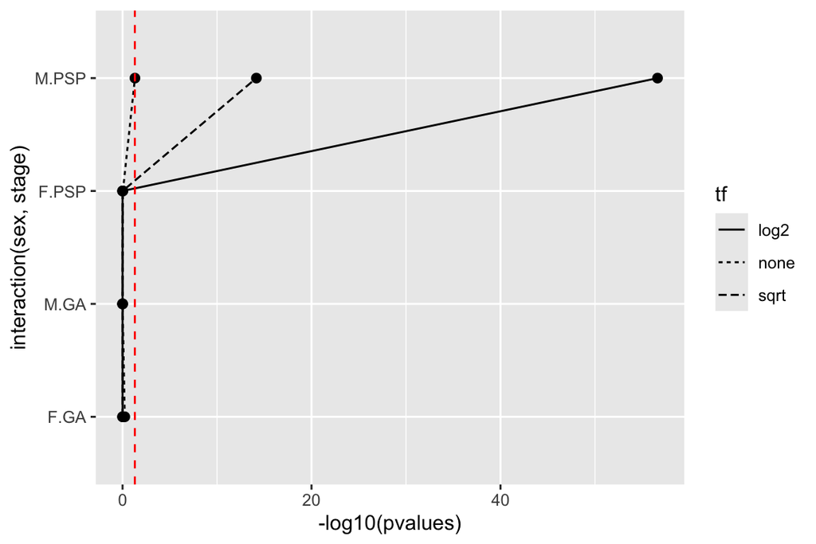

```r
p_res <- data.frame(
        pvalues = c(Ec_M_GA_rht, Ec_M_PSP_rht, Ec_F_GA_rht, Ec_F_PSP_rht,
                    Ec_M_GA_rht.sqrt, Ec_M_PSP_rht.sqrt, Ec_F_GA_rht.sqrt, Ec_F_PSP_rht.sqrt,
                    Ec_M_GA_rht.log2, Ec_M_PSP_rht.log2, Ec_F_GA_rht.log2, Ec_F_PSP_rht.log2),
        sex = c("M", "M", "F", "F", "M", "M", "F", "F", "M", "M", "F", "F"),
        tf = c("none", "none", "none", "none",
               "sqrt", "sqrt", "sqrt", "sqrt",
               "log2", "log2", "log2", "log2"),
        stage = c("GA", "PSP", "GA", "PSP",
                  "GA", "PSP", "GA", "PSP",
                  "GA", "PSP", "GA", "PSP")
)

p_res |>
        ggplot2::ggplot(aes(x = interaction(sex, stage), y = -log10(pvalues), linetype = tf, group = tf)) +
        ggplot2::geom_line() +
        ggplot2::geom_point(size = 2) +
        ggplot2::geom_hline(yintercept = -log10(0.05), colour = "red", linetype = 2) +
        ggplot2::coord_flip()
```

```r
p_res
```

| pvalues | sex | tf | stage |
| --- | --- | --- | --- |
| 9.916009e-01 | M | none | GA |
| 4.880656e-02 | M | none | PSP |
| 5.827926e-01 | F | none | GA |
| 9.239342e-01 | F | none | PSP |
| 1.000000e+00 | M | sqrt | GA |
| 6.869741e-15 | M | sqrt | PSP |
| 9.999962e-01 | F | sqrt | GA |
| 1.000000e+00 | F | sqrt | PSP |
| 1.000000e+00 | M | log2 | GA |
| 2.394047e-57 | M | log2 | PSP |

[output cut: 2 more lines]

The rht was done on request of one of the reviewers. I interpret the result as inconclusive *w.r.t.* the hourglass pattern in *Ectocarpus* development. This is also due to the incongruence between male and female patterns which is not the case for the unicell vs multicell comparison.

Taken together with the `PairwiseTest()` of the unicell vs multicell, the picture that is reinforced is that unicellular stages have a younger transcriptome than the multicellular stages. Due to differences in tissue composition in filamentous *Ectocarpus*, I suspect that the patterns are (in part) driven by tissue composition heterogeneity. Noticeably, in the earlyPSP of *Ectocarpus*, which contains exactly 3-5 cells (thus not influenced by tissue composition), the males are younger than females. However, I think this exploration is beyond the scope of this particular study.

# *Laminaria* and *Saccorhiza* data

Here, we check the TAI for *Saccorhiza polyschides* and *Laminaria digitata*.

## RNA-seq quantification

```bash
nextflow run nf-core/rnaseq -r 3.5 -params-file nf-params_Ldigitata_HG.json -profile singularity,sge

nextflow run nf-core/rnaseq -r 3.5 -params-file nf-params_Spolyschides_HG.json -profile singularity,sge
```

Where the `nf-params_*.json` points to the file locations.

```bash
{
    "input": "/tmp/global2/jlotharukpong/nfcore_rnaseq/Laminaria_digitata.csv",
    "outdir": "/tmp/global2/jlotharukpong/nfcore_rnaseq/Laminaria-digitata_HG",
    "fasta": "/tmp/global2/jlotharukpong/nfcore_rnaseq/Phaeoexplorer_genomes/Laminaria-digitata_MALE.fa",
    "gff": "/tmp/global2/jlotharukpong/annotation_solve/annotation_post/Laminaria-digitata_MALE.clean_gff3.gff",
    "pseudo_aligner": "salmon",
    "salmon_quant_libtype": "A"
}
```

```bash
{
    "input": "/tmp/global2/jlotharukpong/nfcore_rnaseq/Saccorhiza_polyschides_HG.csv",
    "outdir": "/tmp/global2/jlotharukpong/nfcore_rnaseq/Saccorhiza-polyschides_HG",
    "fasta": "/tmp/global2/jlotharukpong/nfcore_rnaseq/Phaeoexplorer_genomes/Saccorhiza-polyschides_MALE.fa",
    "gff": "/tmp/global2/jlotharukpong/annotation_solve/annotation_post/Saccorhiza-polyschides_MALE.clean_gff3.gff",
    "pseudo_aligner": "salmon",
    "salmon_quant_libtype": "A"
}
```

## Gene age inference

### *Laminaria digitata*

TaxID: `80365`.

```bash
genEra \
    -q /ebio/abt5_projects/Phaeoexplorer/data/04__FINAL_PROTEOMES/Laminaria-digitata_MALE_proteins.fa \
    -t 80365 \
    -b /tmp/global2/jlotharukpong/diamond_mkd/nr \
    -d /tmp/global2/jlotharukpong/genEra/taxdump \
    -a sodai_proteins.tsv \
    -f sodai_genomes.tsv \
    -n 20
```

### *Saccorhiza polyschides*

TaxID: `45365`.

```bash
genEra \
    -q /ebio/abt5_projects/Phaeoexplorer/data/04__FINAL_PROTEOMES/Saccorhiza-polyschides_MALE_proteins.fa \
  -t 45365 \
    -b /tmp/global2/jlotharukpong/diamond_mkd/nr \
    -d /tmp/global2/jlotharukpong/genEra/taxdump \
    -a sodai_proteins.tsv \
    -f sodai_genomes.tsv \
    -n 20
```

In the protein list file, we include the *Fucus* and the *Ectocarpus* species. This is to ensure a similar number of PS with *Fucus* and *Ectocarpus*.

### Plotting gene age distribution

```r
library(tidyverse)
library(scales)
```

```r
# Load gene age
Ld_age.all <- readr::read_tsv("data/Ld_HG_default.gene_ages.tsv",
                        col_names = c("tx", "PS", "rank", "tax_rep"),
                        skip = 1)
Sp_age.all <- readr::read_tsv("data/Sp_HG_default.gene_ages.tsv",
                        col_names = c("tx", "PS", "rank", "tax_rep"),
                        skip = 1)
```

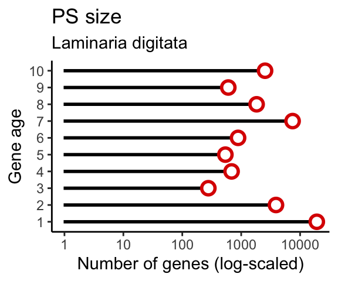

```r
# Plot distribution
Ld_age.all %>%
  dplyr::group_by(rank) %>%
  dplyr::summarise(count = dplyr::n()) %>%
  tidyr::drop_na() %>%
  ggplot2::ggplot(aes(x = factor(rank), y = count)) +
  ggplot2::geom_col(colour = "black", fill = "black", width = 0.1) +
  ggplot2::geom_point(shape = 21, colour = "#DC0000FF", fill = "white", size = 3, stroke = 1.5) +
  ggplot2::labs(title = "PS size",
       subtitle = "Laminaria digitata",
       fill = "GO term",
       y = "Number of genes (log-scaled)",
       x = "Gene age") +
  ggplot2::theme_classic() +
  ggplot2::scale_y_log10() +
  ggplot2::coord_flip()
```

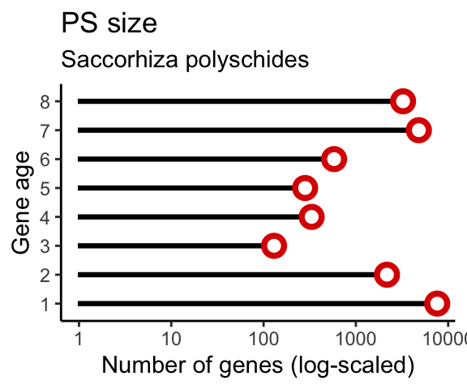

```r
# ggplot2::ggsave(filename = "figures/Ld_age_dist.pdf", device = "pdf", width = 2.5, height = 2.5)

Sp_age.all %>%
  dplyr::group_by(rank) %>%
  dplyr::summarise(count = dplyr::n()) %>%
  tidyr::drop_na() %>%
  ggplot2::ggplot(aes(x = factor(rank), y = count)) +
  ggplot2::geom_col(colour = "black", fill = "black", width = 0.1) +
  ggplot2::geom_point(shape = 21, colour = "#DC0000FF", fill = "white", size = 3, stroke = 2) +
  ggplot2::labs(title = "PS size",
       subtitle = "Saccorhiza polyschides",
       fill = "GO term",
       y = "Number of genes (log-scaled)",
       x = "Gene age") +
  ggplot2::theme_classic() +
  ggplot2::scale_y_log10() +
  ggplot2::coord_flip()
```

```r
# ggplot2::ggsave(filename = "figures/Sp_age_dist.pdf", device = "pdf", width = 2.5, height = 2.5)
```

## Developmental hourglass

### Preprocessing for TAI

```r
library(tidyverse)
library(duckplyr)
library(myTAI)
```

```r
Sp_abundance <- readr::read_tsv("data/Sp_HG.salmon.merged.gene_tpm.tsv")
Ld_abundance <- readr::read_tsv("data/Ld_HG.salmon.merged.gene_tpm.tsv")

# filter genes with mean expression less than 2
Sp_keep <- Sp_abundance[rowMeans(Sp_abundance[-c(1,2)])>2, ]
Ld_keep <- Ld_abundance[rowMeans(Ld_abundance[-c(1,2)])>2, ]
```

The data was then processed to `Ld_PES` and `Sp_PES` in the same way as done for *F. serratus*, *F. distichus* and *Ectocarpus*. The median TPM between replicates were chosen.

#### *Laminaria digitata*

```r
Ld_PES <- readr::read_csv("data/Ld_PES.csv")
```

#### *Saccorhiza polyschides*

```r
Sp_PES <- readr::read_csv("data/Sp_PES.csv")
```

### Plot TAI

```r
#TI stands for transcriptome index
TI.preplot <- function(ExpressionSet, permutations = 1000){
  std <-
    myTAI::bootMatrix(
      ExpressionSet = ExpressionSet,
      permutations  = permutations) %>%
    apply(2, stats::sd)
  TI.out <-
    myTAI::TAI(ExpressionSet) %>%
    tibble::as_tibble(rownames = "Stage", colnames = c("TAI", "PS")) %>%
    dplyr::bind_cols(as_tibble(std)) %>%
    dplyr::rename(TAI = 2, sd = 3)
  return(TI.out)
}
```

```r
get_TAI <- function(PES_all, ordered_stages){
        TI_all <-
                TI.preplot(PES_all)

        TI_combined <-
                TI_SP |>
                rbind(TI_M) |>
                rbind(TI_F) |>
                dplyr::mutate(Stage.common = Stage) |>
                dplyr::mutate(Stage.common = stringr::str_remove(Stage.common, "m_|f_")) |>
                dplyr::mutate(Stage.common = stringr::str_remove(Stage.common, "_stipe|_meristem|_vegfrond|_holdfast")) |>
                dplyr::mutate(Stage.common = stringr::str_replace(Stage.common, "PSP", "SP"))
        TI_combined$Stage.common <- base::factor(TI_combined$Stage.common, ordered_stages)
        return(TI_combined)
}
```

```r
# Fucus style plot
plot_TAI <- function(TI){
        plotTAI_out <- TI |>
                ggplot2::ggplot(
                        aes(x = Stage,
                            y = TAI,
                            group = 1,
                            colour = "#00A087FF",
                            fill = "#00A087FF")) +
                ggplot2::geom_ribbon(
                        aes(ymin = TAI - sd,
                            ymax = TAI + sd
                            ),
                        alpha = 0.1) +
                ggplot2::geom_line(size = 2, lineend = "round")
        return(plotTAI_out)
}

# Ectocarpus style plot
plot_TAI2 <- function(TI){
        plotTAI_out <- TI |>
                ggplot2::ggplot(
                        aes(x = Stage,
                            y = TAI,
                            group = 1,
                            colour = "#E64B35FF",
                            fill = "#E64B35FF")) +
                ggplot2::geom_crossbar(
                        aes(ymin = TAI - sd,
                            ymax = TAI + sd),
                            alpha = 0.5,
                            position = ggplot2::position_dodge(0.55),
                            width = 0.5)
        return(plotTAI_out)
}
```

### sqrt transform

```r
TI_Ld.sqrt <- TI.preplot(myTAI::tf(Ld_PES, sqrt)) # square-root transformation
TI_Sp.sqrt <- TI.preplot(myTAI::tf(Sp_PES, sqrt)) # square-root transformation
```

#### adult stages

```r
TI_Ld.sqrt.matSP <-
        TI_Ld.sqrt |>
        dplyr::filter(stringr::str_detect(Stage, "matSP")) |>
        dplyr::mutate(contains_unicell = dplyr::case_when(
                stringr::str_detect(Stage, "sorus") ~ TRUE,
                .default = FALSE
        ))
TI_Ld.sqrt.matSP <- TI_Ld.sqrt.matSP[order(TI_Ld.sqrt.matSP$TAI),]
TI_Ld.sqrt.matSP$Stage <- factor(TI_Ld.sqrt.matSP$Stage,levels=TI_Ld.sqrt.matSP$Stage)
```

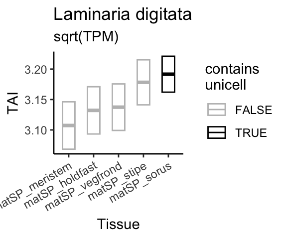

```r
TI_Ld.sqrt.matSP |>
        ggplot2::ggplot(
                aes(x = Stage,
                    y = TAI,
                    colour = contains_unicell)) +
        ggplot2::geom_crossbar(
                aes(ymin = TAI - sd,
                    ymax = TAI + sd),
                alpha = 0.5,
                position = ggplot2::position_dodge(0.55),
                width = 0.5) +
        ggplot2::labs(title = "Laminaria digitata",
                      subtitle = "sqrt(TPM)",
                      x = "Tissue",
                      colour = "contains\nunicell") +
        ggplot2::theme_classic() +
        ggplot2::scale_colour_manual(values=c("grey", "black")) +
        ggplot2::theme(axis.text.x = element_text(angle = 30, vjust = 1, hjust=1))
```

```r
TI_Sp.sqrt.matSP <-
        TI_Sp.sqrt |>
        dplyr::filter(stringr::str_detect(Stage, "matSP")) |>
        dplyr::mutate(contains_unicell = dplyr::case_when(
                stringr::str_detect(Stage, "sorus") ~ TRUE,
                .default = FALSE
        ))

TI_Sp.sqrt.matSP <- TI_Sp.sqrt.matSP[order(TI_Sp.sqrt.matSP$TAI),]
TI_Sp.sqrt.matSP$Stage <- factor(TI_Sp.sqrt.matSP$Stage,levels=TI_Sp.sqrt.matSP$Stage)
```

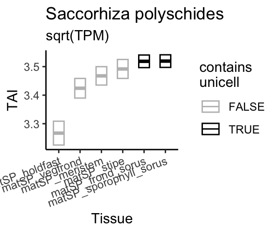

```r
TI_Sp.sqrt.matSP |>
        ggplot2::ggplot(
                aes(x = Stage,
                    y = TAI,
                    colour = contains_unicell)) +
        ggplot2::geom_crossbar(
                aes(ymin = TAI - sd,
                    ymax = TAI + sd),
                alpha = 0.5,
                position = ggplot2::position_dodge(0.55),
                width = 0.5) +
        ggplot2::labs(title = "Saccorhiza polyschides",
                      subtitle = "sqrt(TPM)",
                      x = "Tissue",
                      colour = "contains\nunicell") +
        ggplot2::theme_classic() +
        ggplot2::scale_colour_manual(values=c("grey", "black")) +
        ggplot2::theme(axis.text.x = element_text(angle = 20, vjust = 1, hjust=1))
```

The unicells (meiospores) very likely contributes to driving the TAI higher in the reproductive tissues. The `vegfrond` (analogous tissue to vegtip) represent the average TAI of `matSP` in both species. For simplicity, they will be used in the further analysis.

#### development

```r
# Laminaria
TI_Ld.sqrt.GA <- TI_Ld.sqrt |>
        dplyr::filter(!stringr::str_detect(Stage, "earlySP|4wSP|meristem|stipe|holdfast|matSP_vegfrond")) |>
        dplyr::mutate(Stage = stringr::str_replace(Stage, "matSP_sorus", "meiospore_sorus"))
TI_Ld.sqrt.SP <- TI_Ld.sqrt |>
        dplyr::filter(!stringr::str_detect(Stage, "GA|meristem|stipe|holdfast|sorus")) |>
        dplyr::mutate(Stage = stringr::str_remove(Stage, "_vegfrond")) # vegfrond is the mean TAI of all adult stages
# Saccorhiza
TI_Sp.sqrt.GA <- TI_Sp.sqrt |>
        dplyr::filter(!stringr::str_detect(Stage, "earlySP|4wSP|meristem|stipe|holdfast|matSP_vegfrond")) |>
        dplyr::mutate(Stage = stringr::str_replace(Stage, "matSP_frond_sorus", "meiospore_frond_sorus")) |>
        dplyr::mutate(Stage = stringr::str_replace(Stage, "matSP_sporophyll_sorus", "meiospore_sporophyll_sorus"))

# order the stages
TI_Ld.sqrt.SP$Stage <- factor(TI_Ld.sqrt.SP$Stage, levels = c("earlySP", "4wSP", "matSP"))
TI_Ld.sqrt.GA$Stage <- factor(TI_Ld.sqrt.GA$Stage, levels = c("meiospore_sorus", "f_immGA", "f_matGA"))
TI_Sp.sqrt.GA$Stage <- factor(TI_Sp.sqrt.GA$Stage, levels = c("meiospore_sporophyll_sorus", "meiospore_frond_sorus", "f_immGA", "f_matGA"))
```

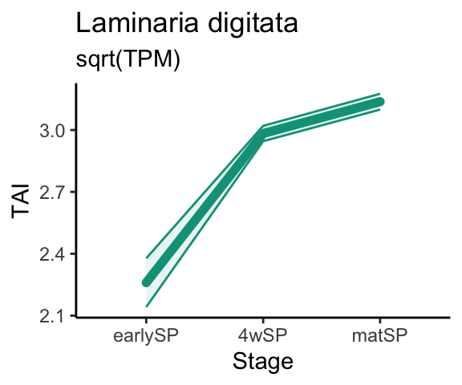

```r
TI_Ld.sqrt.SP |>
        plot_TAI() +
        ggplot2::scale_colour_manual(values="#00A087FF") +
        ggplot2::scale_fill_manual(values="#00A087FF") +
        ggplot2::labs(title = "Laminaria digitata", subtitle = "sqrt(TPM)", x = "Stage") +
        ggplot2::theme_classic() +
        ggplot2::theme(legend.position = "")
```

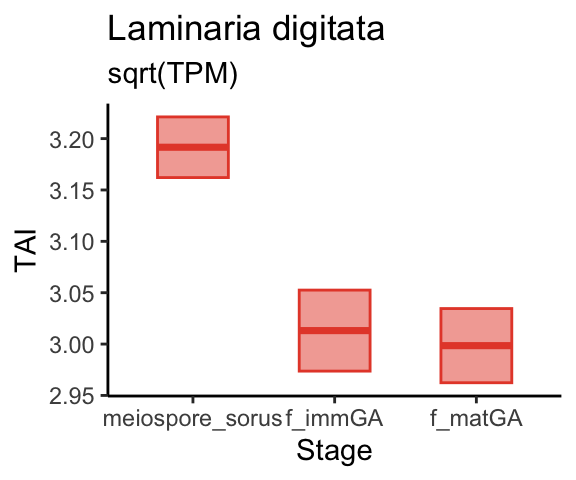

```r
TI_Ld.sqrt.GA |>
        plot_TAI2() +
        ggplot2::scale_colour_manual(values="#E64B35FF") +
        ggplot2::scale_fill_manual(values="#E64B35FF") +
        ggplot2::labs(title = "Laminaria digitata", subtitle = "sqrt(TPM)", x = "Stage") +
        ggplot2::theme_classic() +
        ggplot2::theme(legend.position = "")
```

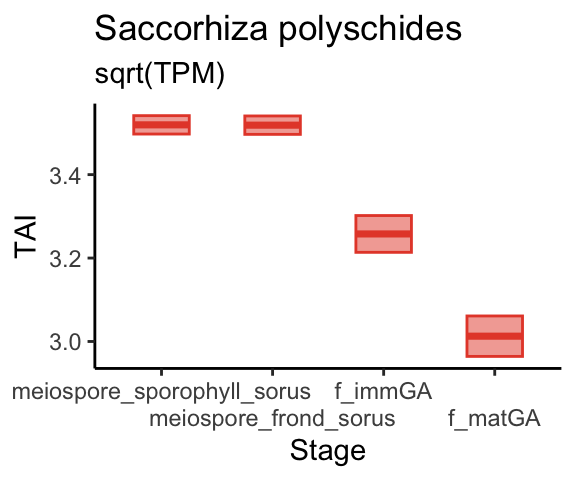

```r
TI_Sp.sqrt.GA |>
        plot_TAI2() +
        ggplot2::scale_colour_manual(values="#E64B35FF") +
        ggplot2::scale_fill_manual(values="#E64B35FF") +
        ggplot2::labs(title = "Saccorhiza polyschides", subtitle = "sqrt(TPM)", x = "Stage") +
        ggplot2::theme_classic() +
        ggplot2::scale_x_discrete(guide = ggplot2::guide_axis(n.dodge=2)) +
        ggplot2::theme(legend.position = "")
```

### log2 transform

```r
TI_Ld.log2 <- TI.preplot(myTAI::tf(Ld_PES, log2, pseudocount = 1)) # log2 transformation
TI_Sp.log2 <- TI.preplot(myTAI::tf(Sp_PES, log2, pseudocount = 1)) # log2 transformation
```

#### development

```r
# Laminaria
TI_Ld.log2.GA <- TI_Ld.log2 |>
        dplyr::filter(!stringr::str_detect(Stage, "earlySP|4wSP|meristem|stipe|holdfast|matSP_vegfrond")) |>
        dplyr::mutate(Stage = stringr::str_replace(Stage, "matSP_sorus", "meiospore_sorus"))
TI_Ld.log2.SP <- TI_Ld.log2 |>
        dplyr::filter(!stringr::str_detect(Stage, "GA|meristem|stipe|holdfast|sorus")) |>
        dplyr::mutate(Stage = stringr::str_remove(Stage, "_vegfrond")) # vegfrond is the mean TAI of all adult stages
# Saccorhiza
TI_Sp.log2.GA <- TI_Sp.log2 |>
        dplyr::filter(!stringr::str_detect(Stage, "earlySP|4wSP|meristem|stipe|holdfast|matSP_vegfrond")) |>
        dplyr::mutate(Stage = stringr::str_replace(Stage, "matSP_frond_sorus", "meiospore_frond_sorus")) |>
        dplyr::mutate(Stage = stringr::str_replace(Stage, "matSP_sporophyll_sorus", "meiospore_sporophyll_sorus"))

# order the stages
TI_Ld.log2.SP$Stage <- factor(TI_Ld.log2.SP$Stage, levels = c("earlySP", "4wSP", "matSP"))
TI_Ld.log2.GA$Stage <- factor(TI_Ld.log2.GA$Stage, levels = c("meiospore_sorus", "f_immGA", "f_matGA"))
TI_Sp.log2.GA$Stage <- factor(TI_Sp.log2.GA$Stage, levels = c("meiospore_sporophyll_sorus", "meiospore_frond_sorus", "f_immGA", "f_matGA"))
```

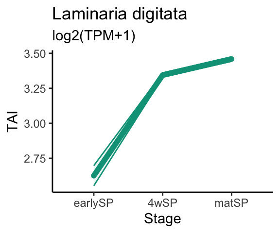

```r
TI_Ld.log2.SP |>
        plot_TAI() +
        ggplot2::scale_colour_manual(values="#00A087FF") +
        ggplot2::scale_fill_manual(values="#00A087FF") +
        ggplot2::labs(title = "Laminaria digitata", subtitle = "log2(TPM+1)", x = "Stage") +
        ggplot2::theme_classic() +
        ggplot2::theme(legend.position = "")
```

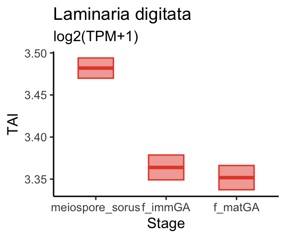

```r
TI_Ld.log2.GA |>
        plot_TAI2() +
        ggplot2::scale_colour_manual(values="#E64B35FF") +
        ggplot2::scale_fill_manual(values="#E64B35FF") +
        ggplot2::labs(title = "Laminaria digitata", subtitle = "log2(TPM+1)", x = "Stage") +
        ggplot2::theme_classic() +
        ggplot2::theme(legend.position = "")
```

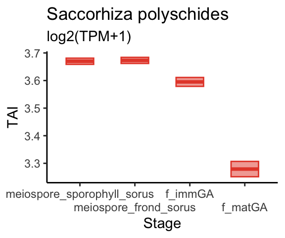

```r
TI_Sp.log2.GA |>
        plot_TAI2() +
        ggplot2::scale_colour_manual(values="#E64B35FF") +
        ggplot2::scale_fill_manual(values="#E64B35FF") +
        ggplot2::labs(title = "Saccorhiza polyschides", subtitle = "log2(TPM+1)", x = "Stage") +
        ggplot2::theme_classic() +
        ggplot2::scale_x_discrete(guide = ggplot2::guide_axis(n.dodge=2)) +
        ggplot2::theme(legend.position = "")
```

## Transcriptome distance of earlySP in *L. digitata*

Is earlySP in *L. digitata* close in distance to the conserved stage in *Fucus*?

### Running orthofinder

We first run orthofinder to obtain related groups of genes.

```bash
# I first made a directory that contains the Fs, Fd, Ld and Sp peptide sequences
orthofinder -f protein_seq/ -t 24
```

This results in:

From `Statistics_Overall.tsv`

```bash
Number of species in orthogroup Number of orthogroups
1       5090
2       20139
3       3915
4       6852
```

and from `Statistics_PerSpecies.tsv`

```bash
        Fd_tasm Fs_tasm Laminaria-digitata_MALE_proteins        Saccorhiza-polyschides_MALE_proteins
Number of genes 44694   75869   42270   19747
Number of genes in orthogroups  35620   52227   28066   14310
Number of unassigned genes      9074    23642   14204   5437
Percentage of genes in orthogroups      79.7    68.8    66.4    72.5
Percentage of unassigned genes  20.3    31.2    33.6    27.5
Number of orthogroups containing species        27933   31257   14206   11125
Percentage of orthogroups containing species    77.6    86.8    39.5    30.9
Number of species-specific orthogroups  302     2384    2130    274
Number of genes in species-specific orthogroups 891     7509    8303    866
Percentage of genes in species-specific orthogroups     2.0     9.9     19.6    4.4
```

### Convert gene to orthogroups

To capture the expression of in-paralogues, we import the count tables treating orthogroups (OGs) as genes and genes and isoforms as isoforms.

Thus, as you’d expect, we use the `tximport` library. We also use the script from [`OthoMantegazza/crossr`](https://github.com/othomantegazza/crossr/blob/master/R/parsers.R) called `parse_orthogroups.R`. This is needed because it was quicker to parse the `Orthogroup.tsv` file.

```r
library(tximport)
library(tidyverse)
library(myTAI)
```

### Parse orthogroups

```r
# From https://github.com/othomantegazza/crossr/blob/master/R/parsers.R
parse_orthogroups <- function(path_2_ogroups)
{
  orthogroups <- scan(path_2_ogroups, what = "",
                      skip = 1, sep = "\n")

  ### Not sure why some values are separated by tab in file
  orthogroups <- gsub("\t", ", ",
                      orthogroups)

  orthogroups <- strsplit(orthogroups, ", ")

  ### names of orthogroup are read in first list element
  names(orthogroups) <- sapply(orthogroups,
                               function(i) i[1])
  orthogroups <- lapply(orthogroups,
                        function(i) i[-1])

  ## Dont know why some elements in orthogroups are null ( "" )
  orthogroups <- lapply(orthogroups,
                        function(i) i[i != ""])


  return(orthogroups)
}
```

```r
OG_tx2gene <-
  parse_orthogroups("data/LdSpFucus/Orthogroups.tsv") %>%
  stack() %>%
  tidyr::as_tibble() %>%
  dplyr::rename(GeneID = values) %>%
  dplyr::rename(OG = ind) %>%
  dplyr::relocate(GeneID) %>%
  # dplyr::filter(str_detect(GeneID, "digitata")) %>%
  dplyr::mutate(GeneID = str_remove(GeneID, "\\.p[0-9].*"))



OG_tx2gene <- OG_tx2gene |>
  # dplyr::mutate(OG = as.character(OG)) |>
  dplyr::rename(tx = GeneID)
```

```r
Ld_tx2gene <- readr::read_tsv("data/Ld.salmon_tx2gene.tsv", col_names = c("tx", "gene_id")) |>
        dplyr::select(1, 2) |>
        dplyr::mutate(tx = stringr::str_replace(tx, "mRNA_", "prot_"))
Ld_tx2gene2OG <-
  Ld_tx2gene |>
  dplyr::left_join(OG_tx2gene, by = "tx") |>
  tidyr::drop_na()
```

```r
Ld_PES.OG <-
        Ld_PES |>
        dplyr::select(1,2,"earlySP") |>
        tidyr::pivot_longer(!c(rank, gene_id), names_to = "SampleID", values_to = "TPM") |>
        dplyr::left_join(Ld_tx2gene2OG) |>
        tidyr::drop_na() |>
        duckplyr::summarise(TPM = sum(TPM), .by = c(SampleID, OG)) # sum TPM

# 12099 unique gene IDs
# 9124 unique orthogroups

Ld_PES.OG.filt <-
        Ld_PES.OG |>
        dplyr::select(-SampleID) |>
        dplyr::mutate(stage = "earlySP", species = "Ld")

Ld_PES.OG.filt.log2 <-
        Ld_PES.OG.filt |>
        dplyr::filter(TPM > 0) |>
        dplyr::mutate(TPM = log2(TPM+1))
# we keep 1,826 orthogroups
```

#### Load *Fucus serratus* data

```r
Fs_PES <- readr::read_csv("data/Fs_PES.log2.csv")

Fs_PES.OG <- Fs_PES |>
  dplyr::rename(tx = GeneID) |>
  dplyr::left_join(OG_tx2gene) |>
  dplyr::select(-c(gamete, matSP, PS)) |>
  tidyr::drop_na() |>
  tidyr::pivot_longer(!c(tx,OG), names_to = "stage", values_to = "TPM") |>
  duckplyr::summarise(TPM = sum(TPM), .by = c(stage, OG)) |> # sum TPM
  dplyr::mutate(species = "Fs")
```

#### Load *Fucus distichus* data

```r
Fd_PES <- readr::read_csv("data/Fd_PES.log2.csv")

Fd_PES.OG <- Fd_PES |>
  dplyr::rename(tx = GeneID) |>
  dplyr::left_join(OG_tx2gene) |>
  dplyr::select(-c(gamete, matSP, PS)) |>
  tidyr::drop_na() |>
  tidyr::pivot_longer(!c(tx,OG), names_to = "stage", values_to = "TPM") |>
  duckplyr::summarise(TPM = sum(TPM), .by = c(stage, OG)) |> # sum TPM
  dplyr::mutate(species = "Fd")
```

#### Function to permute distance

This function uses `philentropy`.

```r
permute_dist <- function(OG.bind.wide, method = "manhattan", bootstraps = 10, focal_col = 6) {
  nCol <- ncol(OG.bind.wide)
  perm_matrix <- matrix(ncol = nCol, nrow = bootstraps)
  bootsample <- NULL

  for (i in seq_len(bootstraps)) {
    bootsample <- OG.bind.wide[sample(seq_len(nrow(OG.bind.wide)), nrow(OG.bind.wide), replace = TRUE), ]

    # Compute the distance
    dist_matrix <- philentropy::distance(t(bootsample), method = method, use.row.names = TRUE, mute.message = TRUE)

    # Ensure proper subsetting
    if (nrow(dist_matrix) >= focal_col && ncol(dist_matrix) >= focal_col) {
      bootdist <- dist_matrix[focal_col, -focal_col]
    } else {
      stop("The distance matrix does not have the expected dimensions")
    }

    # Adjust perm_matrix dimensions to match bootdist length if necessary
    if (i == 1 && ncol(perm_matrix) != length(bootdist)) {
      cat("Adjusting perm_matrix dimensions to match bootdist length\n")
      perm_matrix <- matrix(ncol = length(bootdist), nrow = bootstraps)
    }

    if (length(bootdist) == ncol(perm_matrix)) {
      perm_matrix[i, ] <- bootdist
    } else {
      stop("The length of bootdist does not match the number of columns in perm_matrix")
    }
  }

  return(perm_matrix)
}
```

### Compute and display transcriptome distance

The idea here is to bind and then summarise.

```r
OG.both <- intersect(Fs_PES.OG$OG, Ld_PES.OG.filt.log2$OG)

# we keep 840 orthogroups.

OG.bind <- rbind(Fs_PES.OG, Ld_PES.OG.filt.log2) |>
  dplyr::filter(OG %in% OG.both)
# normalise TPM by sum of all TPM
OG.bind.scale <- OG.bind |>
  dplyr::mutate(TPM = TPM/sum(TPM), .by = stage)

OG.bind.wide <- OG.bind.scale |>
  select(-species) |>
  tidyr::pivot_wider(names_from = "stage", values_from = "TPM") |>
  column_to_rownames(var = "OG")

OG.manhattan.raw <-
  philentropy::distance(
    t(OG.bind.wide),
    method = "manhattan",
    use.row.names = TRUE)
```

```
## Metric: 'manhattan'; comparing: 6 vectors.
```

```r
OG.manhattan.raw.bs <- permute_dist(OG.bind.wide, method = "manhattan", bootstraps = 1000)
```

```
## Adjusting perm_matrix dimensions to match bootdist length
```

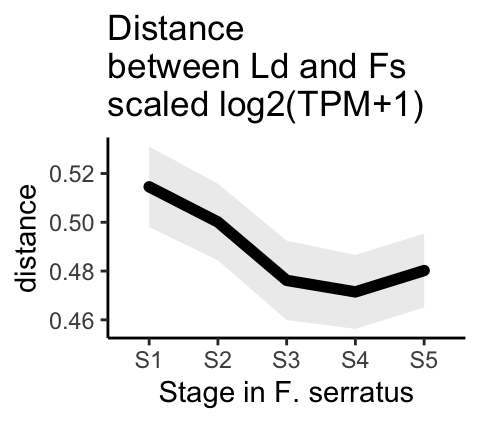

```r
# ^ for the real figure, I used 50,000 permutations.
OG.manhattan.raw.bs.sd <- apply(OG.manhattan.raw.bs, 2, stats::sd)

OG.manhattan.filt <- OG.manhattan.raw[6,1:5]
data.frame(dist = OG.manhattan.filt,
           stage = names(OG.manhattan.filt),
           sd = OG.manhattan.raw.bs.sd) |>
  ggplot2::ggplot(aes(x = stage, y = dist, group = 1)) +
  ggplot2::geom_ribbon(
    aes(ymin = dist - sd,
        ymax = dist + sd
        ),
    alpha = 0.1) +
  ggplot2::geom_line(size = 2, lineend = "round") +
  ggplot2::theme_classic() +
  ggplot2::labs(title = "Distance\nbetween Ld and Fs\nscaled log2(TPM+1)",
                y = "distance",
                x = "Stage in F. serratus")
```

```r
# ggplot2::ggsave(filename = "figures/Ld_Fs_dist.pdf", device = "pdf", width = 2.5, height = 2.2)
```

```r
OG.both <- intersect(Fd_PES.OG$OG, Ld_PES.OG.filt.log2$OG)

# we keep 880 orthogroups.

OG.bind <- rbind(Fd_PES.OG, Ld_PES.OG.filt.log2) |>
  dplyr::filter(OG %in% OG.both)
# normalise TPM by sum of all TPM
OG.bind.scale <- OG.bind |>
  dplyr::mutate(TPM = TPM/sum(TPM), .by = stage)

OG.bind.wide <- OG.bind.scale |>
  select(-species) |>
  tidyr::pivot_wider(names_from = "stage", values_from = "TPM") |>
  column_to_rownames(var = "OG")

OG.manhattan.raw <-
  philentropy::distance(
    t(OG.bind.wide),
    method = "manhattan",
    use.row.names = TRUE)
```

```
## Metric: 'manhattan'; comparing: 7 vectors.
```

```r
OG.manhattan.raw.bs <- permute_dist(OG.bind.wide, method = "manhattan", bootstraps = 1000, focal_col = 7)
```

```
## Adjusting perm_matrix dimensions to match bootdist length
```

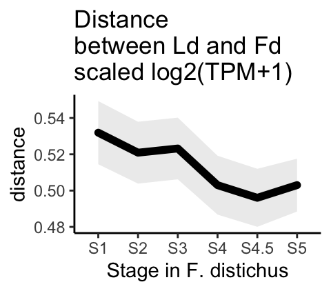

```r
OG.manhattan.raw.bs.sd <- apply(OG.manhattan.raw.bs, 2, stats::sd)

OG.manhattan.filt <- OG.manhattan.raw[7,-7]
data.frame(dist = OG.manhattan.filt,
           stage = names(OG.manhattan.filt),
           sd = OG.manhattan.raw.bs.sd) |>
  ggplot2::ggplot(aes(x = stage, y = dist, group = 1)) +
  ggplot2::geom_ribbon(
    aes(ymin = dist - sd,
        ymax = dist + sd
        ),
    alpha = 0.1) +
  ggplot2::geom_line(size = 2, lineend = "round") +
  ggplot2::theme_classic() +
  ggplot2::labs(title = "Distance\nbetween Ld and Fd\nscaled log2(TPM+1)",
                y = "distance",
                x = "Stage in F. distichus")
```

```r
# ggplot2::ggsave(filename = "figures/Ld_Fd_dist.pdf", device = "pdf", width = 2.5, height = 2.2)
```

Based on the manhattan distance, we see that the earlySP in *Laminaria* is similar to the most conserved stages in both species of *Fucus*. This suggests that the supposedly ‘early conservation’ pattern we see with just the few stages in fact is the tail-end of the hourglass pattern in *Laminaria*. Unfortunately, we cannot go earlier in the development of *Laminaria* because it was difficult to extract the early embryo without interference from maternal tissue of the female gametophyte.

Note: by resampling the OGs and computing the orthogroups, I managed to obtain the spread of the distances.

# Transcriptome distance in *Ectocarpus* vs *Fucus*.

## Load data

```r
Ec_PES_M <-
  readr::read_csv(file = "data/Ec_PES_32m.csv", show_col_types = FALSE)
Ec_PES_F <-
  readr::read_csv(file = "data/Ec_PES_25f.csv", show_col_types = FALSE)
Fs_PES <- readr::read_csv("data/Fs_PES.csv") |> dplyr::select(-c(gamete,matSP))
Fd_PES <- readr::read_csv("data/Fd_PES.csv") |> dplyr::select(-c(gamete,matSP))
```

### Parse orthogroups

```r
# From https://github.com/othomantegazza/crossr/blob/master/R/parsers.R
parse_orthogroups <- function(path_2_ogroups)
{
  orthogroups <- scan(path_2_ogroups, what = "",
                      skip = 1, sep = "\n")

  ### Not sure why some values are separated by tab in file
  orthogroups <- gsub("\t", ", ",
                      orthogroups)

  orthogroups <- strsplit(orthogroups, ", ")

  ### names of orthogroup are read in first list element
  names(orthogroups) <- sapply(orthogroups,
                               function(i) i[1])
  orthogroups <- lapply(orthogroups,
                        function(i) i[-1])

  ## Dont know why some elements in orthogroups are null ( "" )
  orthogroups <- lapply(orthogroups,
                        function(i) i[i != ""])


  return(orthogroups)
}
```

```r
OG_tx2gene <-
  parse_orthogroups("data/Results_Nov29/Orthogroups/Orthogroups.tsv") %>%
  stack() %>%
  tidyr::as_tibble() %>%
  dplyr::rename(GeneID = values) %>%
  dplyr::rename(OG = ind) %>%
  dplyr::relocate(GeneID) %>%
  # dplyr::filter(str_detect(GeneID, "ser_|dis_")) %>%
  dplyr::mutate(GeneID = str_remove(GeneID, "\\.p[0-9].*"))
```

### Replace gene with OG

```r
# TPM gene -> TPM orthogroup (sum) -> apply log transformation
processOG <- function(PES, OG_tx2gene){
        PES.out <- PES |>
                dplyr::left_join(OG_tx2gene) |>
                tidyr::drop_na() |>
                dplyr::select(-c(GeneID, PS)) |>
                tidyr::pivot_longer(!OG, names_to = "stage", values_to = "exp") |>
                dplyr::summarise(exp = sum(exp), .by = c(stage,OG)) |>
                tidyr::pivot_wider(names_from = "stage", values_from = "exp")
        return(PES.out)
}

Fs_PES.OG <-
        processOG(Fs_PES,OG_tx2gene) |> # from 8,291 to 5,669
        rename_with(~paste0(., "_Fs"), -1)
Fd_PES.OG <-
        processOG(Fd_PES,OG_tx2gene) |> # from 7,953 to 5,514
        rename_with(~paste0(., "_Fd"), -1)
Ec_PES_M.OG <-
        processOG(Ec_PES_M,OG_tx2gene) |> # from 11,571 to 6,282
        rename_with(~paste0(., "_EcM"), -1)
Ec_PES_F.OG <-
        processOG(Ec_PES_F,OG_tx2gene) |> # from 11,571 to 6,282
        rename_with(~paste0(., "_EcF"), -1)
```

```r
Big_OG_expression_Join <-
        Fs_PES.OG |>
        inner_join(Fd_PES.OG) |>
        inner_join(Ec_PES_M.OG) |>
        inner_join(Ec_PES_F.OG)
# we now have 1,880 OGs
# representing:
OG_tx2gene |>
        dplyr::filter(OG %in% Big_OG_expression_Join$OG) |>
        dplyr::filter(str_detect(GeneID, "Ec-"))
# 2,968 genes in Ec
OG_tx2gene |>
        dplyr::filter(OG %in% Big_OG_expression_Join$OG) |>
        dplyr::filter(str_detect(GeneID, "ser_"))
# 2,433 genes in Fs
OG_tx2gene |>
        dplyr::filter(OG %in% Big_OG_expression_Join$OG) |>
        dplyr::filter(str_detect(GeneID, "dis_"))
# 2,134 genes in Fd

# BUT can we do better? Join for only Fs vs Ec and Fd vs Ec.
Fs_OG_expression_Join <-
        Fs_PES.OG |>
        inner_join(Ec_PES_M.OG) |>
        inner_join(Ec_PES_F.OG)
# we now have 3,196 OGs
# representing:
OG_tx2gene |>
        dplyr::filter(OG %in% Fs_OG_expression_Join$OG) |>
        dplyr::filter(str_detect(GeneID, "Ec-"))
# 5,122 genes in Ec
OG_tx2gene |>
        dplyr::filter(OG %in% Fs_OG_expression_Join$OG) |>
        dplyr::filter(str_detect(GeneID, "ser_"))
# 3,931 genes in Fs

Fd_OG_expression_Join <-
        Fd_PES.OG |>
        inner_join(Ec_PES_M.OG) |>
        inner_join(Ec_PES_F.OG)
# we now have 3,160 OGs
# representing:
OG_tx2gene |>
        dplyr::filter(OG %in% Fd_OG_expression_Join$OG) |>
        dplyr::filter(str_detect(GeneID, "Ec-"))
# 4,840 genes in Ec
OG_tx2gene |>
        dplyr::filter(OG %in% Fd_OG_expression_Join$OG) |>
        dplyr::filter(str_detect(GeneID, "dis_"))
# 3,495 genes in Fd
```

```r
Fs_OG_expression_Join <- Fs_OG_expression_Join |> column_to_rownames(var = "OG")
Fd_OG_expression_Join <- Fd_OG_expression_Join |> column_to_rownames(var = "OG")
```

## Distance/similarity

### Pearson correlation

Fucus serratus

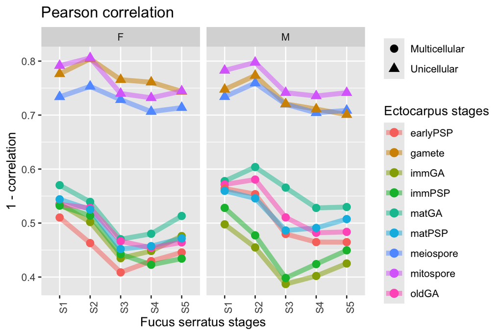

```r
ncol_Fs <- stringr::str_detect(colnames(Fs_OG_expression_Join), "_Fs")
ncol_Ec_M <- stringr::str_detect(colnames(Fs_OG_expression_Join), "_EcM")
ncol_Ec_F <- stringr::str_detect(colnames(Fs_OG_expression_Join), "_EcF")
ExpData <- log2(Fs_OG_expression_Join+1)
M = cor(x = ExpData[,ncol_Fs],
        y = ExpData[,ncol_Ec_F|ncol_Ec_M],
        method = "pearson")
M_melt <- reshape2::melt(M)

M_melt.prep <- M_melt |>
        dplyr::mutate(Fs_stage = stringr::str_remove(Var1, "_Fs")) |>
        tidyr::separate(Var2, into = c("Ec_stage", "Sex"), sep="_(?=[^_]+$)") |>
        dplyr::mutate(Sex = stringr::str_remove(Sex, "Ec")) |>
        dplyr::mutate(type = case_when(
                Ec_stage %in% c("meiospore", "mitospore", "gamete") ~ "Unicellular",
                .default = "Multicellular"
        ))
M_melt.prep |>
        ggplot2::ggplot(aes(x = Fs_stage,
                            y = 1 - value,
                            shape = type,
                            colour = Ec_stage,
                            group = Ec_stage)) +
        ggplot2::geom_line(linewidth = 2, alpha  = 0.5) +
        ggplot2::geom_point(size = 3) +
        labs(shape = NULL) +
        ggplot2::facet_grid(~ Sex) +
        ggplot2::labs(x = "Fucus serratus stages",
                      y = "1 - correlation",
                      title = "Pearson correlation",
                      colour = "Ectocarpus stages") +
        ggplot2::theme(axis.text.x = element_text(angle = 90, vjust = 1, hjust=1))
```

```r
ggplot2::ggsave(filename = "Fs_Ec_pearson.pdf", device = "pdf", width = 4.5, height = 2.5)
```

Fucus distichus

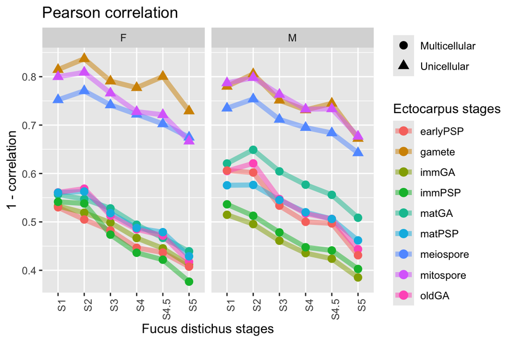

```r
ncol_Fd <- stringr::str_detect(colnames(Fd_OG_expression_Join), "_Fd")
ncol_Ec_M <- stringr::str_detect(colnames(Fd_OG_expression_Join), "_EcM")
ncol_Ec_F <- stringr::str_detect(colnames(Fd_OG_expression_Join), "_EcF")
ExpData <- log2(Fd_OG_expression_Join+1)
M = cor(x = ExpData[,ncol_Fd],
        y = ExpData[,ncol_Ec_F|ncol_Ec_M],
        method = "pearson")
M_melt <- reshape2::melt(M)

M_melt.prep <- M_melt |>
        dplyr::mutate(Fd_stage = stringr::str_remove(Var1, "_Fd")) |>
        tidyr::separate(Var2, into = c("Ec_stage", "Sex"), sep="_(?=[^_]+$)") |>
        dplyr::mutate(Sex = stringr::str_remove(Sex, "Ec")) |>
        dplyr::mutate(type = case_when(
                Ec_stage %in% c("meiospore", "mitospore", "gamete") ~ "Unicellular",
                .default = "Multicellular"
        ))
M_melt.prep |>
        ggplot2::ggplot(aes(x = Fd_stage,
                            y = 1 - value,
                            shape = type,
                            colour = Ec_stage,
                            group = Ec_stage)) +
        ggplot2::geom_line(linewidth = 2, alpha  = 0.5) +
        ggplot2::geom_point(size = 3) +
        labs(shape = NULL) +
        ggplot2::facet_grid(~ Sex) +
        ggplot2::labs(x = "Fucus distichus stages",
                      y = "1 - correlation",
                      title = "Pearson correlation",
                      colour = "Ectocarpus stages") +
        ggplot2::theme(axis.text.x = element_text(angle = 90, vjust = 1, hjust=1))
```

```r
ggplot2::ggsave(filename = "Fd_Ec_pearson.pdf", device = "pdf", width = 4.5, height = 2.5)
```

### Spearman correlation

Fucus serratus

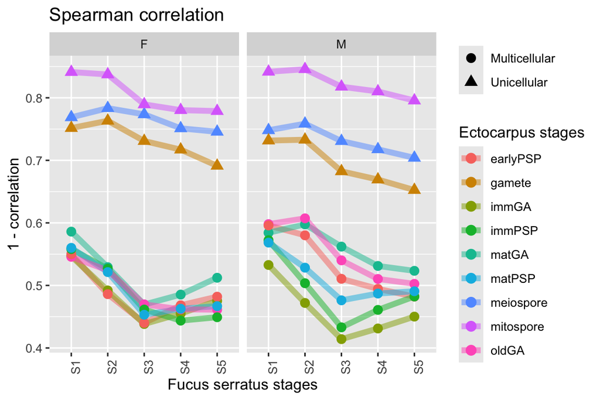

```r
ncol_Fs <- stringr::str_detect(colnames(Fs_OG_expression_Join), "_Fs")
ncol_Ec_M <- stringr::str_detect(colnames(Fs_OG_expression_Join), "_EcM")
ncol_Ec_F <- stringr::str_detect(colnames(Fs_OG_expression_Join), "_EcF")
ExpData <- log2(Fs_OG_expression_Join+1)
M = cor(x = ExpData[,ncol_Fs],
        y = ExpData[,ncol_Ec_F|ncol_Ec_M],
        method = "spearman")
M_melt <- reshape2::melt(M)

M_melt.prep <- M_melt |>
        dplyr::mutate(Fs_stage = stringr::str_remove(Var1, "_Fs")) |>
        tidyr::separate(Var2, into = c("Ec_stage", "Sex"), sep="_(?=[^_]+$)") |>
        dplyr::mutate(Sex = stringr::str_remove(Sex, "Ec")) |>
        dplyr::mutate(type = case_when(
                Ec_stage %in% c("meiospore", "mitospore", "gamete") ~ "Unicellular",
                .default = "Multicellular"
        ))
M_melt.prep |>
        ggplot2::ggplot(aes(x = Fs_stage,
                            y = 1 - value,
                            shape = type,
                            colour = Ec_stage,
                            group = Ec_stage)) +
        ggplot2::geom_line(linewidth = 2, alpha  = 0.5) +
        ggplot2::geom_point(size = 3) +
        labs(shape = NULL) +
        ggplot2::facet_grid(~ Sex) +
        ggplot2::labs(x = "Fucus serratus stages",
                      y = "1 - correlation",
                      title = "Spearman correlation",
                      colour = "Ectocarpus stages") +
        ggplot2::theme(axis.text.x = element_text(angle = 90, vjust = 1, hjust=1))
```

```r
ggplot2::ggsave(filename = "Fs_Ec_spearman.pdf", device = "pdf", width = 3.8, height = 2.5)
```

Fucus distichus

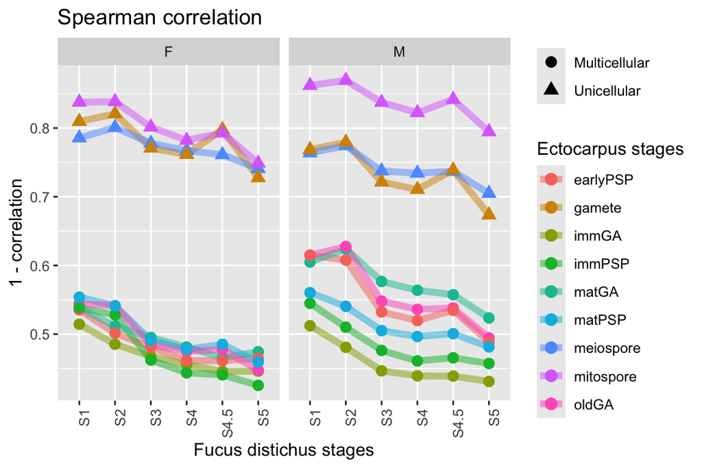

```r
ncol_Fd <- stringr::str_detect(colnames(Fd_OG_expression_Join), "_Fd")
ncol_Ec_M <- stringr::str_detect(colnames(Fd_OG_expression_Join), "_EcM")
ncol_Ec_F <- stringr::str_detect(colnames(Fd_OG_expression_Join), "_EcF")
ExpData <- log2(Fd_OG_expression_Join+1)
M = cor(x = ExpData[,ncol_Fd],
        y = ExpData[,ncol_Ec_F|ncol_Ec_M],
        method = "spearman")
M_melt <- reshape2::melt(M)

M_melt.prep <- M_melt |>
        dplyr::mutate(Fd_stage = stringr::str_remove(Var1, "_Fd")) |>
        tidyr::separate(Var2, into = c("Ec_stage", "Sex"), sep="_(?=[^_]+$)") |>
        dplyr::mutate(Sex = stringr::str_remove(Sex, "Ec")) |>
        dplyr::mutate(type = case_when(
                Ec_stage %in% c("meiospore", "mitospore", "gamete") ~ "Unicellular",
                .default = "Multicellular"
        ))
M_melt.prep |>
        ggplot2::ggplot(aes(x = Fd_stage,
                            y = 1 - value,
                            shape = type,
                            colour = Ec_stage,
                            group = Ec_stage)) +
        ggplot2::geom_line(linewidth = 2, alpha  = 0.5) +
        ggplot2::geom_point(size = 3) +
        labs(shape = NULL) +
        ggplot2::facet_grid(~ Sex) +
        ggplot2::labs(x = "Fucus distichus stages",
                      y = "1 - correlation",
                      title = "Spearman correlation",
                      colour = "Ectocarpus stages") +
        ggplot2::theme(axis.text.x = element_text(angle = 90, vjust = 1, hjust=1))
```

```r
ggplot2::ggsave(filename = "Fd_Ec_spearman.pdf", device = "pdf", width = 3.8, height = 2.5)
```

### Manhattan distance

Fucus serratus

```r
ncol_Fs <- stringr::str_detect(colnames(Fs_OG_expression_Join), "_Fs")
ncol_Ec_M <- stringr::str_detect(colnames(Fs_OG_expression_Join), "_EcM")
ncol_Ec_F <- stringr::str_detect(colnames(Fs_OG_expression_Join), "_EcF")
ExpData <- log2(Fs_OG_expression_Join+1)

M <- philentropy::distance(t(ExpData), use.row.names = TRUE, method = "manhattan")
```

```
## Metric: 'manhattan'; comparing: 23 vectors.
```

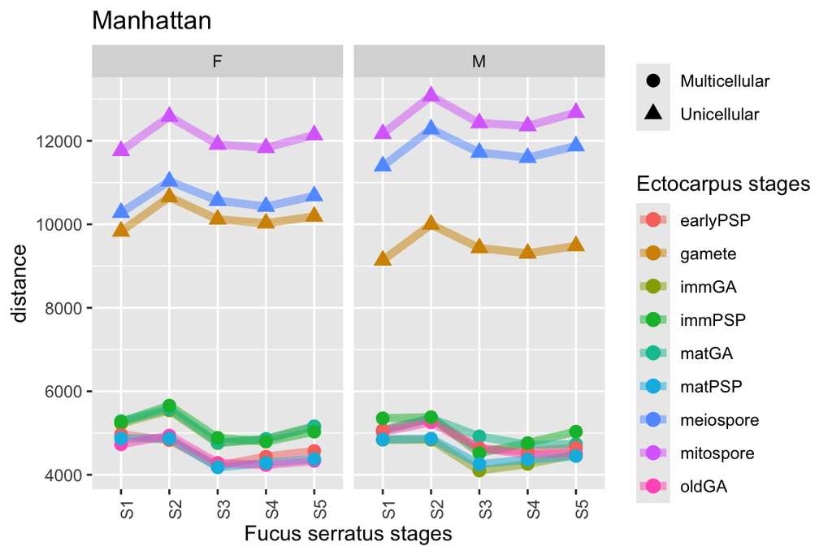

```r
M2 <- M[ncol_Fs, ncol_Ec_F|ncol_Ec_M]

M_melt <- reshape2::melt(M2)

M_melt.prep <- M_melt |>
        dplyr::mutate(Fs_stage = stringr::str_remove(Var1, "_Fs")) |>
        tidyr::separate(Var2, into = c("Ec_stage", "Sex"), sep="_(?=[^_]+$)") |>
        dplyr::mutate(Sex = stringr::str_remove(Sex, "Ec")) |>
        dplyr::mutate(type = case_when(
                Ec_stage %in% c("meiospore", "mitospore", "gamete") ~ "Unicellular",
                .default = "Multicellular"
        ))
M_melt.prep |>
        ggplot2::ggplot(aes(x = Fs_stage,
                            y = value,
                            shape = type,
                            colour = Ec_stage,
                            group = Ec_stage)) +
        ggplot2::geom_line(linewidth = 2, alpha  = 0.5) +
        ggplot2::geom_point(size = 3) +
        labs(shape = NULL) +
        ggplot2::facet_grid(~ Sex) +
        ggplot2::labs(x = "Fucus serratus stages",
                      y = "distance",
                      title = "Manhattan",
                      colour = "Ectocarpus stages") +
        ggplot2::theme(axis.text.x = element_text(angle = 90, vjust = 1, hjust=1))
```

```r
ggplot2::ggsave(filename = "Fs_Ec_Manhattan.pdf", device = "pdf", width = 3.8, height = 2.5)
```

Fucus distichus

```r
ncol_Fd <- stringr::str_detect(colnames(Fd_OG_expression_Join), "_Fd")
ncol_Ec_M <- stringr::str_detect(colnames(Fd_OG_expression_Join), "_EcM")
ncol_Ec_F <- stringr::str_detect(colnames(Fd_OG_expression_Join), "_EcF")
ExpData <- log2(Fd_OG_expression_Join+1)

M <- philentropy::distance(t(ExpData), use.row.names = TRUE, method = "manhattan")
```

```
## Metric: 'manhattan'; comparing: 24 vectors.
```

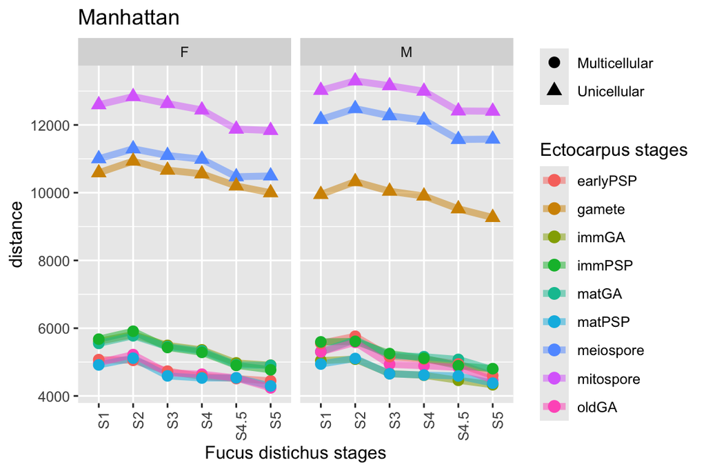

```r
M2 <- M[ncol_Fd, ncol_Ec_F|ncol_Ec_M]

M_melt <- reshape2::melt(M2)

M_melt.prep <- M_melt |>
        dplyr::mutate(Fd_stage = stringr::str_remove(Var1, "_Fd")) |>
        tidyr::separate(Var2, into = c("Ec_stage", "Sex"), sep="_(?=[^_]+$)") |>
        dplyr::mutate(Sex = stringr::str_remove(Sex, "Ec")) |>
        dplyr::mutate(type = case_when(
                Ec_stage %in% c("meiospore", "mitospore", "gamete") ~ "Unicellular",
                .default = "Multicellular"
        ))
M_melt.prep |>
        ggplot2::ggplot(aes(x = Fd_stage,
                            y = value,
                            shape = type,
                            colour = Ec_stage,
                            group = Ec_stage)) +
        ggplot2::geom_line(linewidth = 2, alpha  = 0.5) +
        ggplot2::geom_point(size = 3) +
        labs(shape = NULL) +
        ggplot2::facet_grid(~ Sex) +
        ggplot2::labs(x = "Fucus distichus stages",
                      y = "distance",
                      title = "Manhattan",
                      colour = "Ectocarpus stages") +
        ggplot2::theme(axis.text.x = element_text(angle = 90, vjust = 1, hjust=1))
```

```r
ggplot2::ggsave(filename = "Fd_Ec_Manhattan.pdf", device = "pdf", width = 3.8, height = 2.5)
```

### JSD metric

Fucus serratus

```r
ncol_Fs <- stringr::str_detect(colnames(Fs_OG_expression_Join), "_Fs")
ncol_Ec_M <- stringr::str_detect(colnames(Fs_OG_expression_Join), "_EcM")
ncol_Ec_F <- stringr::str_detect(colnames(Fs_OG_expression_Join), "_EcF")
ExpData <- log2(Fs_OG_expression_Join+1)

ExpDat.norm <- apply(ExpData, 2, function(x) x/sum(x)) %>% as.data.frame()
# colSums(ExpDat.norm)
M <- philentropy::distance(t(ExpDat.norm), use.row.names = TRUE, method = "jensen-shannon")
```

```
## Metric: 'jensen-shannon' using unit: 'log'; comparing: 23 vectors.
```

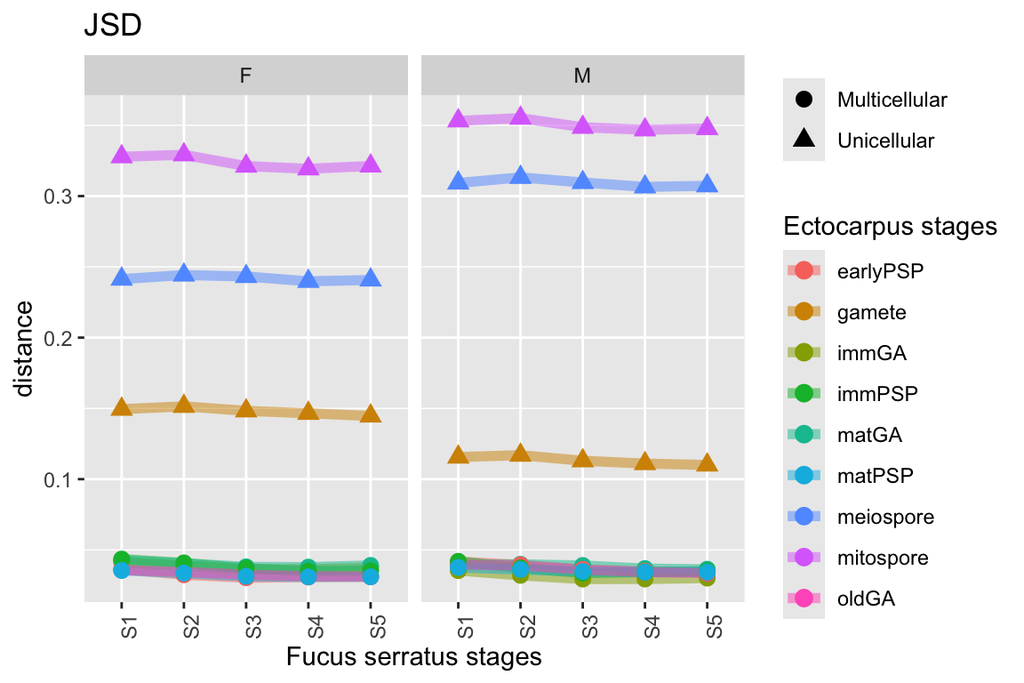

```r
M2 <- M[ncol_Fs, ncol_Ec_F|ncol_Ec_M]

M_melt <- reshape2::melt(M2)

M_melt.prep <- M_melt |>
        dplyr::mutate(Fs_stage = stringr::str_remove(Var1, "_Fs")) |>
        tidyr::separate(Var2, into = c("Ec_stage", "Sex"), sep="_(?=[^_]+$)") |>
        dplyr::mutate(Sex = stringr::str_remove(Sex, "Ec")) |>
        dplyr::mutate(type = case_when(
                Ec_stage %in% c("meiospore", "mitospore", "gamete") ~ "Unicellular",
                .default = "Multicellular"
        ))
M_melt.prep |>
        ggplot2::ggplot(aes(x = Fs_stage,
                            y = value,
                            shape = type,
                            colour = Ec_stage,
                            group = Ec_stage)) +
        ggplot2::geom_line(linewidth = 2, alpha  = 0.5) +
        ggplot2::geom_point(size = 3) +
        labs(shape = NULL) +
        ggplot2::facet_grid(~ Sex) +
        ggplot2::labs(x = "Fucus serratus stages",
                      y = "distance",
                      title = "JSD",
                      colour = "Ectocarpus stages") +
        ggplot2::theme(axis.text.x = element_text(angle = 90, vjust = 1, hjust=1))
```

```r
ggplot2::ggsave(filename = "Fs_Ec_JSD.pdf", device = "pdf", width = 3.8, height = 2.5)
```

Fucus distichus

```r
ncol_Fd <- stringr::str_detect(colnames(Fd_OG_expression_Join), "_Fd")
ncol_Ec_M <- stringr::str_detect(colnames(Fd_OG_expression_Join), "_EcM")
ncol_Ec_F <- stringr::str_detect(colnames(Fd_OG_expression_Join), "_EcF")
ExpData <- log2(Fd_OG_expression_Join+1)

ExpDat.norm <- apply(ExpData, 2, function(x) x/sum(x)) %>% as.data.frame()
# colSums(ExpDat.norm)
M <- philentropy::distance(t(ExpDat.norm), use.row.names = TRUE, method = "jensen-shannon")
```

```
## Metric: 'jensen-shannon' using unit: 'log'; comparing: 24 vectors.
```

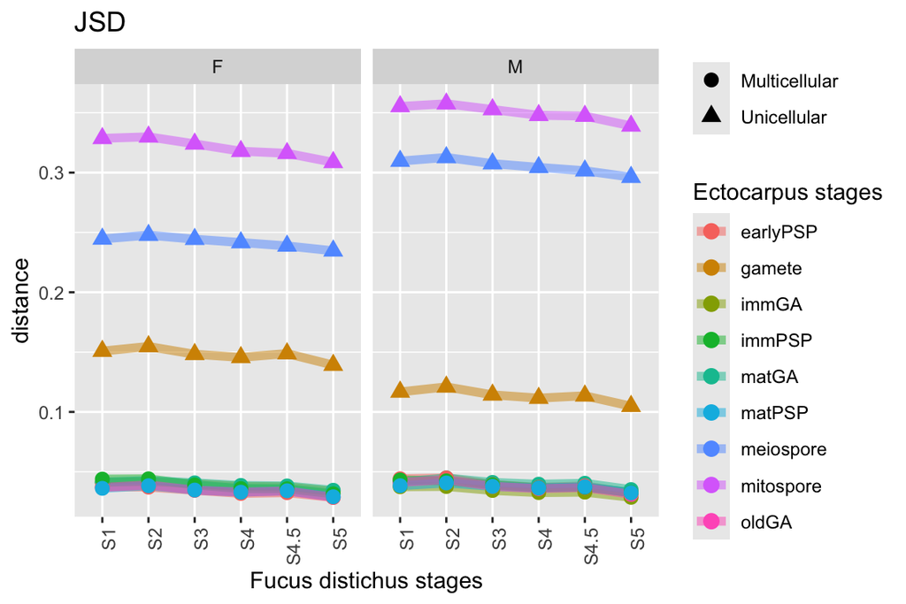

```r
M2 <- M[ncol_Fd, ncol_Ec_F|ncol_Ec_M]

M_melt <- reshape2::melt(M2)

M_melt.prep <- M_melt |>
        dplyr::mutate(Fd_stage = stringr::str_remove(Var1, "_Fd")) |>
        tidyr::separate(Var2, into = c("Ec_stage", "Sex"), sep="_(?=[^_]+$)") |>
        dplyr::mutate(Sex = stringr::str_remove(Sex, "Ec")) |>
        dplyr::mutate(type = case_when(
                Ec_stage %in% c("meiospore", "mitospore", "gamete") ~ "Unicellular",
                .default = "Multicellular"
        ))
M_melt.prep |>
        ggplot2::ggplot(aes(x = Fd_stage,
                            y = value,
                            shape = type,
                            colour = Ec_stage,
                            group = Ec_stage)) +
        ggplot2::geom_line(linewidth = 2, alpha  = 0.5) +
        ggplot2::geom_point(size = 3) +
        labs(shape = NULL) +
        ggplot2::facet_grid(~ Sex) +
        ggplot2::labs(x = "Fucus distichus stages",
                      y = "distance",
                      title = "JSD",
                      colour = "Ectocarpus stages") +
        ggplot2::theme(axis.text.x = element_text(angle = 90, vjust = 1, hjust=1))
```

```r
ggplot2::ggsave(filename = "Fd_Ec_JSD.pdf", device = "pdf", width = 3.8, height = 2.5)
```